# 2022_04_26_Revision_LongCovid_biomarkers

Sabrina

2 June 2022

# Contents

```r
rm(list = ls())

library(tidyverse)
library(kableExtra)
library(readxl)
library(pROC)
library(plotROC)
library(ggpubr)

library(caret)
library(InformationValue)
library(cvms)


inputF = "./"

setwd("/scicore/home/hutterg/GROUP/2022_Etter_COVID_revisions/")
```

# 1 Question

**Are any of the CSF or plasma protein predictive of long-COVID?**

- ROC-AUC
- Logistic regression

# 2 Dataset

## 2.1 metadata

only 27 patients with info for long covid or non long covid

```r
metadata0 <- read_excel(paste0(inputF,"data/COVID-19 severity index ver3IJ.xlsx"), sheet = 2)%>%
  dplyr::rename(StudyID=`Study ID`, LongCOVID=`Long-COVID`, severity_score=`Severity Score`)%>%
  mutate(LongCOVID=ifelse(LongCOVID==1, "long_covid", ifelse(LongCOVID==0, "non_long_covid", LongCOVID)))

table(metadata0$LongCOVID)
```

```
##
##              died        long_covid lost to follow up                NA
##                 6                15                 3                 4
##    non_long_covid
##                12
```

```r
metadata <- metadata0%>%
  dplyr::filter(LongCOVID=="long_covid"| LongCOVID=="non_long_covid")

kable(metadata) %>%
  kable_styling(position = "center", bootstrap_options = c("striped", "hover")) %>%
  scroll_box(width = "800px", height = "400px")
```

| StudyID | Usb Pat Number | USZ Pat Number | Age | Sex | Pre-existing illness | died in hospital | NeuroCOVID Stage | Follow-up | LongCOVID | severity_score | Main neurological symptom |
| --- | --- | --- | --- | --- | --- | --- | --- | --- | --- | --- | --- |
| NC001 | 3595467 | NA | 52 | male | NA | 0 | II | memory problems, difficulties in daily activities | long_covid | 4 | NA |
| NC002 | 3142334 | NA | 52 | female | NA | 0 | II | concentration problems, memory problems, fatigue, change of smell | long_covid | 4 | NA |
| NC004 | 3757171 | NA | 48 | female | CLL | 0 | II | concentration problems, memory problems, fatigue, difficulties in daily activities | long_covid | 4 | NA |
| NC005 | 2145457 | NA | 59 | male | arterial hypertension, diabetes mellitus, MGUS | 0 | II | concentration problems, memory problems | long_covid | 4 | NA |
| NC006 | 3216230 | NA | 68 | female | arterial hypertension, chronic kidney failure, pavk | 0 | I | difficulties in daily activities | non_long_covid | 5 | NA |
| NC008 | 3364085 | NA | 98 | male | NA | 0 | I | concetration problems, fatigue | long_covid | 4 | NA |
| NC009 | 2169956 | NA | 68 | female | arterial hypertension | 0 | I | memory problems | long_covid | 4 | NA |
| NC010 | 3310453 | NA | 63 | male | arterial hypertension, diabetes mellitus | 0 | III | fatigue | long_covid | 9 | NA |
| NC012 | 2203623 | NA | 51 | male | coronar heart disease, prediabetes, arterial hypertension, adipositas, dyslipidemia | 0 | I | memory problems, difficulties in daily activities | non_long_covid | 4 | NA |
| NC014 | 3353505 | NA | 68 | female | myasthenia gravis | 0 | II | fatigue, speech difficulties, muscle pain, change of taste, difficulties in daily activities | non_long_covid | 4 | NA |
| NC015 | 3130581 | NA | 34 | male | ventricular septal defect, pulmonal hypertension | 0 | I | NA | non_long_covid | 4 | NA |
| NC016 | 3611593 | NA | 66 | male | coronar heart disease, cardiomyopathy, dyslipidemia | 0 | I | NA | non_long_covid | 4 | NA |
| NC017 | 2125588 | NA | 61 | male | multiple sclerosis | 0 | I | change of taste, muslce pain | non_long_covid | 2 | NA |
| NC020 | 3561454 | NA | 74 | male | coronar heart disease | 0 | II | concentration problems, fatigue | long_covid | 5 | NA |
| NC022 | 3015823 | NA | 64 | female | diabetes mellitus | 0 | III | difficulties in daily activities | long_covid | 9 | NA |
| NC023 | 3802283 | NA | 64 | male | chronic kidney disease | 0 | III | fatigue | long_covid | 9 | NA |
| NC025 | 3806094 | NA | 55 | male | hypercholesterinemia | 0 | I | NA | non_long_covid | 4 | NA |
| NC026 | 3214781 | NA | 58 | male | adipositas, microgyria, structural epilepsy | 0 | I | muslce pain | long_covid | 4 | NA |
| NC027 | 3654646 | NA | 33 | female | NA | 0 | I | NA | non_long_covid | 2 | NA |
| NC028 | 3162072 | NA | 36 | male | diabetes mellitus, coronar heart disease, AF, structural epilepsy | 0 | I | memory problems | long_covid | 4 | NA |
| NC029 | 3787720 | NA | 69 | female | NA | 0 | I | NA | non_long_covid | 2 | NA |
| NC030 | 3779712 | NA | 22 | female | NA | 0 | I | NA | non_long_covid | 2 | NA |
| NC031 | 3810044 | NA | 23 | female | NA | 0 | I | NA | non_long_covid | 2 | NA |
| NC032 | 3748242 | NA | 22 | male | dyslipidemia, arterial hypertension | 0 | I | NA | non_long_covid | NA | NA |
| NC033 | 3252218 | NA | 52 | male | NA | 0 | II | concentration problems, fatigue, change of smell | long_covid | 2 | NA |
| NC034 | 3798407 | NA | 23 | female | NA | 0 | I | concetration problems | long_covid | 2 | NA |
| NC035 | 3600045 | NA | 27 | female | NA | 0 | I | concetration problems | long_covid | 2 | NA |

```r
df <- read.csv(paste0(inputF,"data/data_marginalized_neuroCOVID.csv"))%>%
  dplyr::rename(COVID_class=stageGroup, StudyID=X)%>%
  dplyr::relocate(COVID_class, .after = StudyID)%>%
  dplyr::filter(StudyID %in% metadata$StudyID)
```

## 2.2 CSF

23 patients for CSF

```r
csf <- df%>%
  dplyr::select(StudyID, COVID_class, starts_with("CSF"))%>%
  left_join(dplyr::select(metadata, StudyID, LongCOVID, severity_score), by = "StudyID")%>%
  dplyr::filter(!is.na(CSF_NMNAT1))%>%
  mutate(LongCOVID_01=ifelse(LongCOVID=="long_covid", 1, 0))%>%
  dplyr::relocate(c(LongCOVID, LongCOVID_01, severity_score) ,.after = COVID_class)

colnames(csf) <- gsub("^CSF_","", colnames(csf))

kable(csf) %>%
  kable_styling(position = "center", bootstrap_options = c("striped", "hover")) %>%
  scroll_box(width = "800px", height = "400px")
```

| StudyID | COVID_class | LongCOVID | LongCOVID_01 | severity_score | NMNAT1 | NRP2 | MAPT | CADM3 | GDNF | UNC5C | VWC2 | Siglec_9 | CLM_6 | EZR | SMOC2 | NBL1 | EFNA4 | SCARB2 | NCAN | PRTG | ROBO2 | CRTAM | RGMA | PLXNB3 | CPA2 | CD38 | SMPD1 | MSR1 | Alpha_2_MRAP | … |
| --- | --- | --- | --- | --- | --- | --- | --- | --- | --- | --- | --- | --- | --- | --- | --- | --- | --- | --- | --- | --- | --- | --- | --- | --- | --- | --- | --- | --- | --- | --- |
| NC002 | II | long_covid | 1 | 4 | 3.1036481 | 7.066840 | 3.052474 | 8.128146 | 0.1275125 | 3.977402 | 6.016290 | 4.560238 | 5.234239 | 3.168662 | 5.121269 | 5.472076 | 2.734546 | 6.444690 | 10.065924 | 4.341622 | 5.708427 | 0.5863287 | 11.03231 | 4.886250 | 2.855734 | 6.725975 | 3.421162 | 5.041564 | 6.529011 | … |
| NC004 | II | long_covid | 1 | 4 | 0.6889978 | 5.842225 | 2.066719 | 7.533956 | 0.0095486 | 2.953935 | 3.696252 | 2.772315 | 4.085565 | 2.088443 | 3.751166 | 5.542911 | 1.071552 | 4.802062 | 9.860655 | 3.475590 | 4.641568 | 0.4484768 | 10.32733 | 4.018509 | 1.581542 | 3.703281 | 2.040392 | 3.400262 | 4.974120 | … |
| NC005 | II | long_covid | 1 | 4 | 0.3883658 | 6.748517 | 3.350922 | 8.258622 | -0.0031057 | 4.404878 | 6.763165 | 4.009880 | 4.435234 | 3.320516 | 5.465394 | 5.598007 | 2.319077 | 6.206156 | 10.104987 | 4.443371 | 5.452825 | 0.0233331 | 10.78566 | 4.464000 | 2.714477 | 6.644065 | 2.454062 | 3.731687 | 6.332034 | … |
| NC006 | I | non_long_covid | 0 | 5 | 1.9928084 | 7.031480 | 5.251789 | 8.234081 | -0.0895412 | 4.652137 | 6.758226 | 4.735062 | 5.460610 | 3.382541 | 6.270960 | 5.199642 | 2.335120 | 6.939707 | 9.954056 | 4.362768 | 5.648137 | 0.3326812 | 11.18381 | 4.819203 | 2.255272 | 6.568373 | 2.585743 | 5.321322 | 6.722978 | … |
| NC008 | I | long_covid | 1 | 4 | 2.7963148 | 6.977647 | 3.576602 | 8.287971 | -0.0031057 | 4.199389 | 6.674975 | 3.959270 | 4.861434 | 2.888906 | 5.334263 | 5.442497 | 2.720937 | 6.708526 | 10.098626 | 4.566441 | 5.753225 | 1.6692722 | 11.15351 | 4.976980 | 2.205897 | 6.797305 | 3.202202 | 5.038147 | 6.624774 | … |
| NC009 | I | long_covid | 1 | 4 | 2.2257437 | 6.922425 | 3.612003 | 7.895492 | -0.0093257 | 4.415637 | 6.172630 | 4.207876 | 5.232707 | 2.955146 | 5.687749 | 5.461315 | 2.473481 | 6.814228 | 10.035514 | 4.408360 | 5.780770 | 0.4264205 | 11.23438 | 5.293214 | 3.284462 | 6.009083 | 3.234162 | 4.567430 | 6.414272 | … |
| NC010 | III | long_covid | 1 | 9 | 3.2269022 | 7.463147 | 4.950668 | 8.211696 | -0.0502912 | 5.098002 | 6.768225 | 5.287421 | 5.473268 | 4.053638 | 6.326892 | 5.088078 | 2.941370 | 7.413943 | 10.026945 | 5.113360 | 5.312385 | 1.5725214 | 10.99621 | 4.685928 | 2.648121 | 6.338281 | 2.677416 | 5.839376 | 7.229467 | … |
| NC012 | I | non_long_covid | 0 | 4 | 2.6426548 | 6.836427 | 2.460072 | 7.855582 | -0.0031057 | 3.178459 | 5.176165 | 4.181230 | 3.886174 | 3.020266 | 5.201364 | 5.626067 | 2.450777 | 5.693506 | 9.941406 | 4.224091 | 5.091045 | 1.3878922 | 11.00575 | 5.029100 | 2.968367 | 7.123925 | 3.496082 | 4.396057 | 5.973014 | … |
| NC015 | I | non_long_covid | 0 | 4 | 2.2810613 | 7.295687 | 4.875305 | 8.266749 | 0.0063315 | 4.716978 | 7.478640 | 5.205060 | 6.008303 | 2.982230 | 6.197872 | 5.111345 | 3.170533 | 7.314193 | 10.119347 | 4.391371 | 6.308939 | 1.8563103 | 11.30250 | 5.280563 | 2.186353 | 7.100894 | 3.443877 | 5.412073 | 7.006673 | … |
| NC016 | I | non_long_covid | 0 | 4 | 0.4197486 | 7.352652 | 3.918092 | 8.143486 | 0.0299243 | 4.746021 | 6.430520 | 3.893295 | 4.897376 | 2.943723 | 5.527202 | 5.463370 | 2.571292 | 6.689214 | 10.147503 | 4.671022 | 6.590219 | 0.0619316 | 11.53744 | 5.881279 | 3.970321 | 6.867691 | 4.135425 | 4.752384 | 6.754211 | … |
| NC020 | II | long_covid | 1 | 5 | 0.3659495 | 6.158812 | 2.494285 | 7.056234 | -0.0266984 | 3.221295 | 3.819905 | 2.839026 | 3.454671 | 2.372502 | 5.070423 | 5.685372 | 1.848769 | 5.031174 | 9.795591 | 3.243520 | 3.808845 | -0.0042373 | 10.25138 | 3.959234 | 2.665439 | 2.980678 | 1.564654 | 3.395007 | 5.081535 | … |
| NC022 | III | long_covid | 1 | 9 | 2.5298405 | 6.423690 | 2.486342 | 7.519199 | -0.0140442 | 3.060152 | 4.582442 | 4.073730 | 4.463543 | 3.389159 | 5.386805 | 5.572696 | 1.025464 | 6.033150 | 10.084139 | 3.562730 | 4.159408 | 0.4209065 | 10.41990 | 4.220193 | 2.679874 | 6.377034 | 2.094065 | 4.510821 | 6.062232 | … |
| NC023 | III | long_covid | 1 | 9 | 3.5495010 | 7.399522 | 4.900369 | 8.209819 | 0.0204871 | 4.900632 | 7.201874 | 5.112135 | 5.740977 | 3.573540 | 6.379524 | 5.166082 | 2.897866 | 7.247328 | 10.029542 | 5.200571 | 6.359575 | 1.4813926 | 11.36082 | 5.434956 | 2.408636 | 7.033212 | 3.484820 | 5.704648 | 7.302792 | … |
| NC025 | I | non_long_covid | 0 | 4 | 1.9166773 | 6.768817 | 3.417546 | 8.210367 | 0.0440799 | 3.972885 | 5.864174 | 4.158449 | 4.531669 | 2.533584 | 5.066825 | 5.530207 | 2.382315 | 6.115809 | 10.017758 | 4.252882 | 5.726225 | 1.5826430 | 11.17922 | 5.102883 | 2.332274 | 6.335199 | 3.150867 | 4.084508 | 6.209340 | … |
| NC026 | I | long_covid | 1 | 4 | 2.1727816 | 7.405720 | 3.792021 | 8.185819 | 0.1180754 | 4.493893 | 6.558184 | 4.089328 | 5.311750 | 2.744619 | 5.707840 | 5.285628 | 2.891030 | 6.787763 | 10.028024 | 4.614612 | 6.634913 | 1.9621997 | 11.40439 | 6.094087 | 3.608958 | 6.569437 | 4.017217 | 4.951348 | 6.722472 | … |
| NC027 | I | non_long_covid | 0 | 2 | 0.5452798 | 6.508972 | 2.571471 | 7.892537 | 0.1620439 | 3.391812 | 5.150562 | 3.447592 | 3.646253 | 2.660373 | 5.082207 | 5.552922 | 2.290958 | 5.254618 | 9.970408 | 4.096144 | 4.684934 | 0.2163258 | 10.87387 | 4.555034 | 3.367935 | 5.864344 | 3.393967 | 4.074990 | 6.014941 | … |
| NC028 | I | long_covid | 1 | 4 | 2.2977315 | 5.514492 | 2.054161 | 6.733678 | -0.0078242 | 2.562754 | 3.181127 | 3.848425 | 4.106029 | 3.134039 | 4.522179 | 5.561268 | 2.126359 | 5.124408 | 9.452101 | 3.286681 | 2.942033 | 1.3378381 | 10.18084 | 3.829939 | 2.763300 | 5.782256 | 2.391894 | 5.125219 | 5.313014 | … |
| NC029 | I | non_long_covid | 0 | 2 | 2.3289272 | 6.481809 | 3.089170 | 7.516279 | 0.1841353 | 3.530798 | 4.333865 | 3.366337 | 4.207094 | 2.806913 | 4.828898 | 5.705543 | 2.787809 | 5.394610 | 9.944776 | 3.967013 | 4.767331 | 2.3212067 | 10.76648 | 4.748525 | 3.166106 | 4.329748 | 3.235953 | 4.004321 | 5.609497 | … |
| NC030 | I | non_long_covid | 0 | 2 | 0.8503950 | 6.888854 | 3.939769 | 8.084285 | 0.1794167 | 4.568873 | 6.261297 | 3.487672 | 4.335319 | 2.667397 | 5.730734 | 5.276384 | 2.575491 | 6.198201 | 9.977281 | 4.416763 | 5.824569 | 0.6469836 | 11.29166 | 5.069603 | 2.577188 | 6.326549 | 3.079015 | 4.483863 | 6.646747 | … |
| NC031 | I | non_long_covid | 0 | 2 | 0.8548782 | 6.617479 | 2.760620 | 7.997419 | 0.1841353 | 3.827598 | 5.279465 | 3.456927 | 4.350424 | 2.255593 | 4.793088 | 5.573103 | 1.412609 | 5.628060 | 10.014326 | 4.106073 | 4.894871 | 0.6524976 | 10.85624 | 4.878655 | 2.915356 | 5.759238 | 2.979363 | 4.139391 | 5.908357 | … |
| NC033 | II | long_covid | 1 | 2 | 0.5901123 | 7.550671 | 5.374615 | 8.142462 | 0.2092295 | 5.127688 | 6.854471 | 4.711401 | 5.852039 | 2.877690 | 6.044848 | 5.007722 | 2.628926 | 7.456301 | 9.967149 | 4.822515 | 6.890634 | 0.2714665 | 11.70411 | 5.758166 | 1.986792 | 7.821618 | 3.648953 | 4.910321 | 7.383477 | … |
| NC034 | I | long_covid | 1 | 2 | 3.7239209 | 7.330274 | 4.339023 | 8.126381 | 0.1605425 | 4.730725 | 6.641455 | 4.484722 | 5.267151 | 4.015460 | 6.008307 | 5.225138 | 2.736810 | 7.060268 | 9.985841 | 4.609493 | 6.012831 | 0.6249273 | 11.23377 | 5.453728 | 3.410757 | 5.643161 | 2.891375 | 4.490411 | 7.134959 | … |
| NC035 | I | long_covid | 1 | 2 | 0.8548782 | 6.925229 | 3.266920 | 8.027949 | 0.1841353 | 4.257948 | 5.591975 | 3.907207 | 3.800494 | 2.340003 | 5.327558 | 5.438153 | 1.412609 | 6.061280 | 10.007546 | 4.175753 | 5.351451 | 0.6524976 | 11.00495 | 4.670545 | 2.913286 | 5.835418 | 3.586543 | 4.255591 | 6.283547 | … |

```r
# csf.lf <- csf%>%
#   pivot_longer(names_to = "molec", values_to = "exp", !c(StudyID, COVID_class, LongCOVID, severity_score))%>%
#   group_by(LongCOVID, molec)%>%
#   summarise(exp=mean(exp))%>%
#   pivot_wider(names_from = LongCOVID, values_from = exp)

csf.lf <- csf%>%
  pivot_longer(names_to = "molec", values_to = "exp", !c(StudyID, COVID_class, LongCOVID, LongCOVID_01, severity_score))
```

## 2.3 Plasma

27 patients for plasma

```r
plasma <- df%>%
  dplyr::select(StudyID, COVID_class, starts_with("Plasma"))%>%
  left_join(dplyr::select(metadata, StudyID, LongCOVID, severity_score), by = "StudyID")%>%
  mutate(LongCOVID_01=ifelse(LongCOVID=="long_covid", 1, 0))%>%
  dplyr::relocate(c(LongCOVID, LongCOVID_01, severity_score) ,.after = COVID_class)

colnames(plasma) <- gsub("Plasma_","", colnames(plasma))

kable(plasma) %>%
  kable_styling(position = "center", bootstrap_options = c("striped", "hover")) %>%
  scroll_box(width = "800px", height = "400px")
```

| StudyID | COVID_class | LongCOVID | LongCOVID_01 | severity_score | NMNAT1 | NRP2 | MAPT | CADM3 | GDNF | UNC5C | VWC2 | Siglec_9 | CLM_6 | EZR | SMOC2 | NBL1 | EFNA4 | SCARB2 | NCAN | PRTG | ROBO2 | CRTAM | RGMA | PLXNB3 | CPA2 | CD38 | SMPD1 | MSR1 | Alpha_2_MRAP | … |
| --- | --- | --- | --- | --- | --- | --- | --- | --- | --- | --- | --- | --- | --- | --- | --- | --- | --- | --- | --- | --- | --- | --- | --- | --- | --- | --- | --- | --- | --- | --- |
| NC001 | II | long_covid | 1 | 4 | 4.242404 | 7.944084 | -0.0018261 | 3.393584 | 0.1722176 | 4.148390 | 5.486865 | 4.520327 | 6.229993 | 5.795646 | 9.394517 | 4.887949 | 2.579074 | 5.130143 | 8.583377 | 5.169311 | 4.537668 | 5.614485 | 9.907963 | 3.817245 | 8.999453 | 5.038669 | 5.477923 | 7.629459 | 8.095379 | … |
| NC002 | II | long_covid | 1 | 4 | 5.257637 | 8.161505 | 0.0207233 | 3.223598 | 0.3833873 | 3.839145 | 5.708378 | 5.098119 | 6.420868 | 6.504406 | 7.252394 | 4.606410 | 2.776555 | 5.699466 | 8.536500 | 5.516563 | 4.672358 | 4.814561 | 9.560551 | 3.735452 | 8.688765 | 5.979943 | 6.393483 | 7.859324 | 8.532053 | … |
| NC004 | II | long_covid | 1 | 4 | 8.255290 | 8.106154 | 0.0065061 | 3.468718 | 0.0734093 | 4.575271 | 5.468591 | 4.461411 | 6.397626 | 7.415123 | 7.131897 | 5.017443 | 4.043399 | 5.419912 | 8.647660 | 5.312286 | 4.612030 | 6.416476 | 10.130416 | 3.315987 | 7.127584 | 5.680714 | 5.815831 | 7.315271 | 8.835197 | … |
| NC005 | II | long_covid | 1 | 4 | 3.622899 | 8.148381 | -0.0109251 | 2.351556 | -0.0261683 | 4.447497 | 4.662639 | 5.112571 | 6.156481 | 5.612785 | 6.728228 | 4.762996 | 2.871707 | 5.008132 | 8.390853 | 5.637676 | 4.300203 | 5.690758 | 10.159282 | 4.366290 | 8.655113 | 5.300063 | 5.285615 | 6.810136 | 8.590031 | … |
| NC006 | I | non_long_covid | 0 | 5 | 3.484903 | 7.902818 | -0.0054363 | 3.453427 | -0.1869722 | 4.138423 | 4.729770 | 4.454739 | 5.982971 | 5.123478 | 8.009892 | 4.814314 | 2.648017 | 5.844750 | 8.296039 | 4.999464 | 3.933253 | 4.819177 | 10.164577 | 4.200425 | 8.396717 | 5.804539 | 4.400286 | 7.332754 | 8.074604 | … |
| NC008 | I | long_covid | 1 | 4 | 3.944289 | 7.962221 | -0.0109251 | 2.580156 | 2.6202733 | 4.300607 | 5.164909 | 4.382451 | 5.853501 | 6.202535 | 6.888698 | 4.673686 | 2.549237 | 5.321492 | 8.375433 | 5.519246 | 3.913563 | 4.622608 | 10.525212 | 4.274050 | 8.620053 | 5.844153 | 5.197545 | 7.693976 | 8.457231 | … |
| NC009 | I | long_covid | 1 | 4 | 4.678229 | 8.059628 | 0.0042314 | 2.044308 | 0.0238128 | 3.971955 | 5.839315 | 4.726804 | 5.934477 | 6.004455 | 8.224715 | 4.826365 | 2.528265 | 4.661639 | 7.423002 | 5.301723 | 4.625058 | 4.943869 | 10.027731 | 4.000223 | 8.910592 | 5.019770 | 5.421224 | 7.565375 | 8.105365 | … |
| NC010 | III | long_covid | 1 | 9 | 3.680416 | 8.179797 | -0.0166120 | 3.448522 | 2.6107421 | 4.718827 | 5.367758 | 4.961860 | 6.323326 | 6.247546 | 7.741497 | 4.894975 | 3.046277 | 5.937550 | 8.900957 | 5.257671 | 4.302340 | 5.156315 | 10.057064 | 4.636946 | 9.071827 | 5.872954 | 5.124012 | 7.697637 | 8.560581 | … |
| NC012 | I | non_long_covid | 0 | 4 | 3.160859 | 8.092291 | -0.0109251 | 2.777746 | 2.4864733 | 4.370457 | 5.591039 | 5.155401 | 6.082951 | 5.610595 | 7.429518 | 4.905936 | 2.468938 | 4.967852 | 8.175723 | 5.557826 | 4.541843 | 4.986818 | 10.666532 | 4.979920 | 9.812373 | 5.522423 | 5.918335 | 7.969716 | 8.534701 | … |
| NC014 | II | non_long_covid | 0 | 4 | 2.938177 | 8.094365 | 0.0207233 | 1.861668 | 0.3833873 | 4.171775 | 5.142768 | 4.238179 | 5.401508 | 5.532786 | 6.884684 | 4.534910 | 1.193055 | 4.220586 | 8.745090 | 5.398903 | 3.909828 | 4.965041 | 10.600801 | 4.877992 | 9.065475 | 4.797413 | 7.149553 | 7.528524 | 9.811143 | … |
| NC015 | I | non_long_covid | 0 | 4 | 4.450730 | 8.001464 | -0.0097878 | 3.353210 | -0.0013700 | 4.504095 | 5.697527 | 4.794160 | 6.482350 | 5.818159 | 7.171344 | 4.809620 | 2.950980 | 5.199848 | 7.537392 | 5.813213 | 4.783394 | 6.758466 | 9.941720 | 3.371577 | 7.127994 | 5.644895 | 4.561743 | 7.651334 | 8.697667 | … |
| NC016 | I | non_long_covid | 0 | 4 | 4.875601 | 8.105236 | -0.0069443 | 3.681913 | 0.0606256 | 4.388489 | 5.823053 | 4.516905 | 5.994542 | 6.276214 | 8.782140 | 4.897805 | 2.837015 | 6.004999 | 8.972630 | 5.384620 | 5.906055 | 4.505967 | 10.481209 | 3.974344 | 10.804872 | 5.926195 | 5.055820 | 7.894948 | 7.846972 | … |
| NC017 | I | non_long_covid | 0 | 2 | 3.300441 | 8.199209 | 0.0118224 | 3.951102 | 0.4697965 | 4.078225 | 4.767483 | 4.172456 | 5.688340 | 5.764322 | 8.124741 | 4.858829 | 2.714000 | 4.993679 | 8.896887 | 5.109354 | 4.995696 | 5.300617 | 10.316374 | 3.848857 | 9.083647 | 5.272222 | 6.095356 | 7.276903 | 8.238172 | … |
| NC020 | II | long_covid | 1 | 5 | 3.721498 | 8.145819 | -0.0137686 | 4.293174 | -0.0881639 | 5.363502 | 6.351994 | 4.391596 | 6.308238 | 5.989891 | 7.743153 | 4.851190 | 3.338222 | 6.091951 | 8.619305 | 5.559428 | 4.300972 | 5.680477 | 10.216973 | 4.748033 | 9.165275 | 5.661454 | 5.360688 | 7.852011 | 8.686626 | … |
| NC022 | III | long_covid | 1 | 9 | 4.108858 | 8.099431 | 0.0036627 | 1.928975 | 2.4075253 | 4.167346 | 4.861286 | 5.065185 | 6.094833 | 5.813968 | 6.448251 | 4.764467 | 2.337474 | 4.776031 | 8.508502 | 5.054989 | 3.789818 | 5.440655 | 9.477587 | 4.883950 | 9.299056 | 5.492614 | 4.742334 | 7.761787 | 8.825232 | … |
| NC023 | III | long_covid | 1 | 9 | 4.618411 | 8.229713 | -0.0080817 | 4.818758 | 2.4012889 | 5.159261 | 4.869535 | 4.673097 | 7.124853 | 6.394450 | 8.165623 | 4.865551 | 4.025283 | 7.176643 | 8.665791 | 5.250333 | 3.605955 | 5.572259 | 10.133501 | 5.619907 | 9.507841 | 7.732423 | 5.560421 | 8.550290 | 9.799406 | … |
| NC025 | I | non_long_covid | 0 | 4 | 3.406792 | 8.222086 | -0.0052383 | 2.506760 | 2.6227745 | 4.103296 | 5.005440 | 4.335373 | 5.792856 | 6.496104 | 6.912039 | 4.657177 | 2.237268 | 4.410664 | 8.626889 | 4.996990 | 4.532426 | 4.388390 | 10.427970 | 5.349214 | 7.994319 | 4.903563 | 5.554927 | 7.280405 | 9.114011 | … |
| NC026 | I | long_covid | 1 | 4 | 2.255567 | 7.969982 | 0.0195860 | 3.688933 | 0.3585891 | 4.458397 | 5.810260 | 4.513561 | 6.242979 | 5.455462 | 8.058708 | 4.878856 | 2.683213 | 4.884270 | 8.791271 | 5.431546 | 4.768667 | 5.842523 | 9.995463 | 3.870335 | 9.248114 | 4.799521 | 4.448044 | 7.340496 | 7.253317 | … |
| NC027 | I | non_long_covid | 0 | 2 | 3.560570 | 8.240047 | 0.0089789 | 3.450710 | 0.4078009 | 4.717380 | 6.196947 | 4.492311 | 5.724628 | 5.557857 | 8.487186 | 4.903714 | 2.881304 | 4.746988 | 8.519949 | 5.624967 | 5.488554 | 5.446076 | 10.351295 | 4.574820 | 9.818389 | 5.326962 | 5.487480 | 7.532388 | 8.528117 | … |
| NC028 | I | long_covid | 1 | 4 | 3.880369 | 7.937125 | -0.0114938 | 3.123393 | 2.6484042 | 4.463798 | 5.367570 | 4.439602 | 5.562356 | 5.743858 | 8.229125 | 4.780289 | 2.341747 | 4.264474 | 5.881964 | 5.374612 | 5.017003 | 5.447783 | 9.777339 | 3.744887 | 9.946587 | 4.578847 | 3.925405 | 6.917247 | 8.037148 | … |
| NC029 | I | non_long_covid | 0 | 2 | 3.782541 | 8.002672 | 0.0275476 | 3.685687 | 3.0480783 | 4.677812 | 5.158127 | 4.348579 | 6.131762 | 5.678349 | 8.466781 | 5.005525 | 2.540338 | 5.224105 | 8.210946 | 5.645135 | 4.867971 | 5.593272 | 10.722326 | 4.343353 | 9.695272 | 5.501065 | 4.883904 | 7.761941 | 8.331339 | … |
| NC030 | I | non_long_covid | 0 | 2 | 3.027691 | 7.916856 | 0.0269789 | 3.017974 | 0.5197776 | 4.473563 | 5.246068 | 4.121010 | 5.730747 | 5.551042 | 8.276118 | 4.786008 | 2.258337 | 5.051836 | 8.181706 | 5.693571 | 4.477431 | 5.654168 | 10.556403 | 3.410799 | 9.545257 | 5.166269 | 4.224685 | 6.581762 | 7.147876 | … |
| NC031 | I | non_long_covid | 0 | 2 | 4.120421 | 7.993232 | 0.0275476 | 4.152867 | 0.5321767 | 4.907122 | 5.513007 | 4.815219 | 5.809572 | 5.789709 | 8.382031 | 4.769935 | 2.884348 | 5.374055 | 8.608356 | 5.983055 | 4.680111 | 5.344732 | 10.755356 | 4.899613 | 9.501252 | 5.769515 | 5.172474 | 7.245981 | 8.694789 | … |
| NC032 | I | non_long_covid | 0 | NA | 6.496984 | 8.093644 | -0.0018261 | 2.382604 | 0.1722176 | 3.884300 | 4.907955 | 4.852137 | 5.762693 | 6.425326 | 6.978887 | 4.756739 | 2.192754 | 5.304823 | 9.090787 | 5.358551 | 4.001088 | 5.470405 | 10.795923 | 4.298215 | 9.939663 | 5.502999 | 6.028333 | 7.285809 | 8.635509 | … |
| NC033 | II | long_covid | 1 | 2 | 4.113953 | 8.032541 | 0.0146658 | 2.720114 | 0.5317921 | 4.393169 | 5.048888 | 4.838402 | 6.394543 | 6.484696 | 7.363427 | 5.016045 | 2.951095 | 5.604090 | 8.325345 | 5.252271 | 4.063987 | 5.017888 | 10.061213 | 4.508194 | 9.117065 | 5.615942 | 5.138452 | 7.855797 | 8.836217 | … |
| NC034 | I | long_covid | 1 | 2 | 4.097020 | 8.220750 | 0.0247042 | 3.163575 | 2.7620827 | 4.379128 | 5.303542 | 4.837183 | 6.173799 | 6.282904 | 8.300175 | 4.771330 | 2.742593 | 5.209754 | 8.500568 | 5.614007 | 5.035840 | 4.680391 | 10.309587 | 4.194706 | 9.474604 | 4.647675 | 5.263708 | 7.149627 | 7.936314 | … |
| NC035 | I | long_covid | 1 | 2 | 4.932501 | 8.105422 | 0.0275476 | 3.819387 | 0.5321767 | 4.762022 | 4.949697 | 4.456619 | 6.170552 | 6.184049 | 7.815271 | 4.851955 | 2.730898 | 5.202545 | 8.394996 | 5.370345 | 4.938491 | 5.334222 | 10.424356 | 3.916033 | 8.527752 | 5.604765 | 4.959374 | 7.604221 | 8.009549 | … |

```r
plasma.lf <- plasma%>%
  pivot_longer(names_to = "molec", values_to = "exp", !c(StudyID, COVID_class, LongCOVID, LongCOVID_01, severity_score))

# plasma.t <- t(plasma)
# colnames(plasma.t) <- plasma.t[1,]
# plasma.t <- type.convert(as.data.frame(plasma.t[-c(1:4),]))
```

# 3 Prediction long COVID - **CSF**

## 3.1 ROC-AUC Anaylsis long-COVID vs non-long COVID

Computing the ROC-AUC of each molecule with respect to the long-COVID character will let us know which molecule are the best predictors when considered in isolation.

```r
list.csf <- colnames(csf[,6:ncol(csf)])

ROC_AUC_csf <- lapply(list.csf, function(x) {
  roc <- roc(LongCOVID ~ get(x), csf)
  auc <- auc(roc)
  cbind(AUC = auc,
        gene = roc$call$predictor[3],
        variables = eval(x))
})

ROC_AUC_csf1 <- do.call(rbind, ROC_AUC_csf)

kable(ROC_AUC_csf1[order(ROC_AUC_csf1[,"AUC"],decreasing=TRUE),]) %>%
  kable_styling(position = "center", bootstrap_options = c("striped", "hover")) %>%
  scroll_box(width = "800px", height = "400px")
```

| AUC | variables |
| --- | --- |
| 0.785714285714286 | TNFRSF9 |
| 0.781746031746032 | IFN_gamma |
| 0.761904761904762 | TRANCE |
| 0.746031746031746 | Beta_NGF |
| 0.746031746031746 | MMP_1 |
| 0.73015873015873 | THY_1 |
| 0.73015873015873 | N_CDase |
| 0.73015873015873 | ST1A1 |
| 0.722222222222222 | TRAIL |
| 0.722222222222222 | IL13 |
| 0.722222222222222 | MMP_10 |
| 0.698412698412698 | LIF |
| 0.69047619047619 | sFRP_3 |
| 0.69047619047619 | NRTN |
| 0.678571428571429 | CCL25 |
| 0.670634920634921 | IL4 |
| 0.666666666666667 | BCAN |
| 0.666666666666667 | TSLP |
| 0.666666666666667 | TNF |
| 0.666666666666667 | 4E_BP1 |
| 0.658730158730159 | SLAMF1 |
| 0.650793650793651 | EZR |
| 0.650793650793651 | LXN |
| 0.650793650793651 | IL_5R_alpha |
| 0.650793650793651 | IL8 |
| 0.642857142857143 | FcRL2 |
| 0.642857142857143 | IL_12B |
| 0.642857142857143 | IL_24 |
| 0.634920634920635 | GDNF |
| 0.634920634920635 | CLEC10A |

[output cut: 152 more lines]

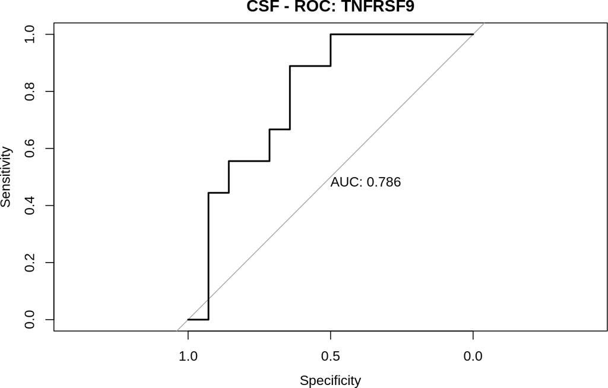

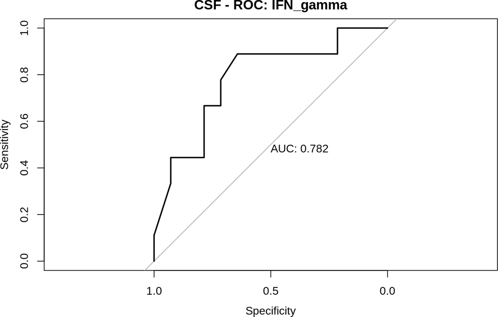

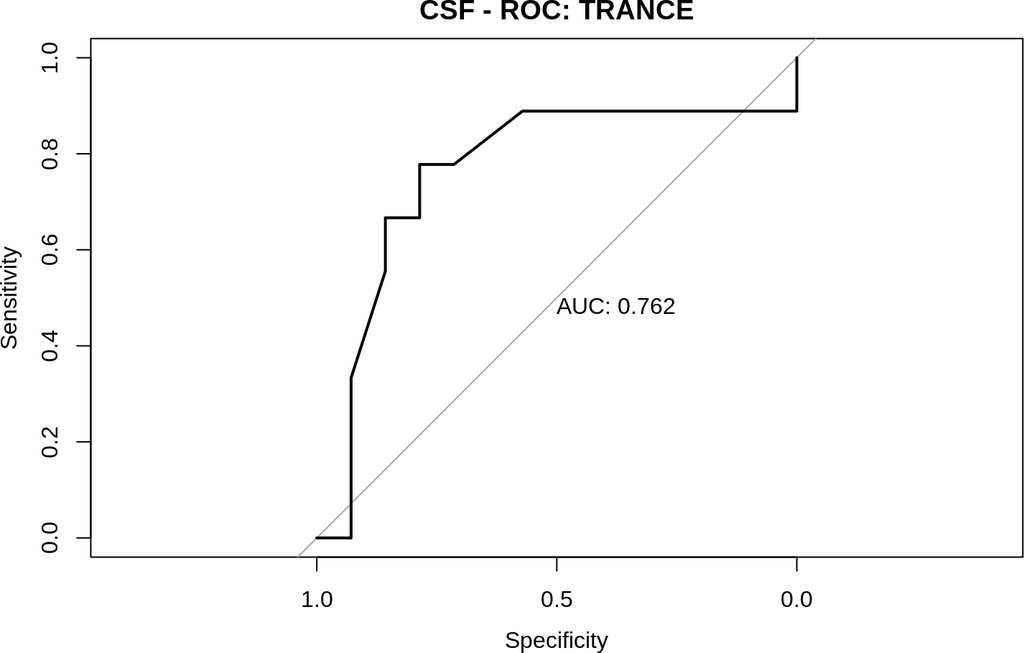

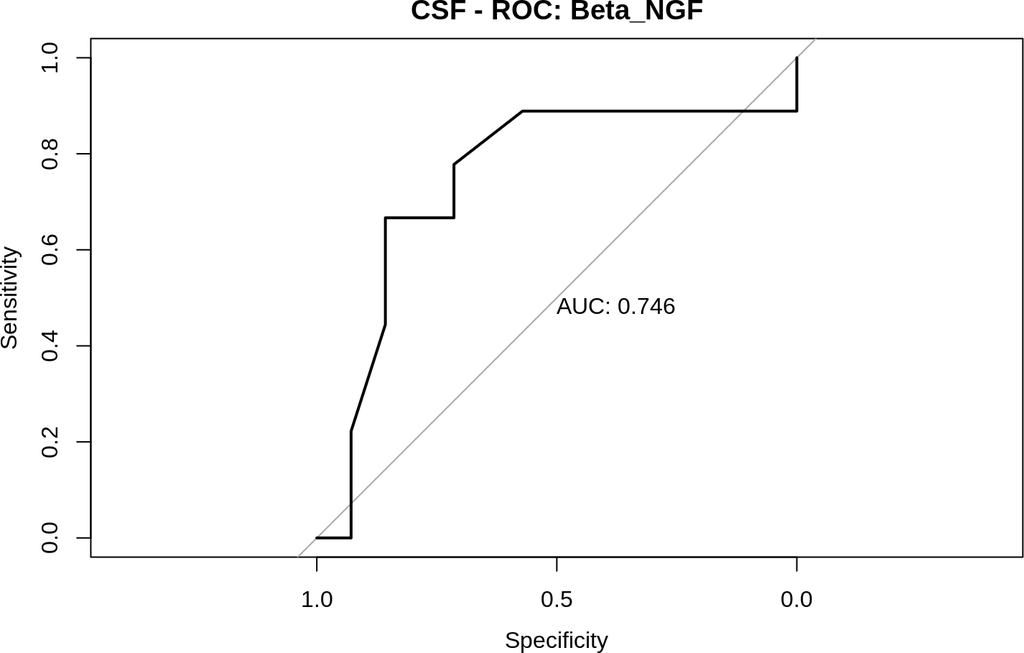

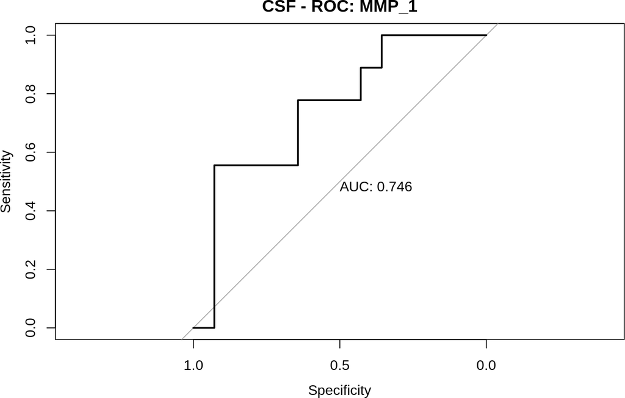

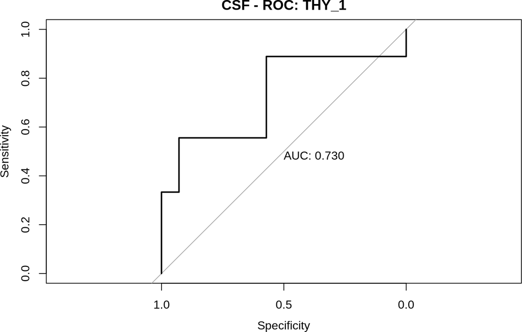

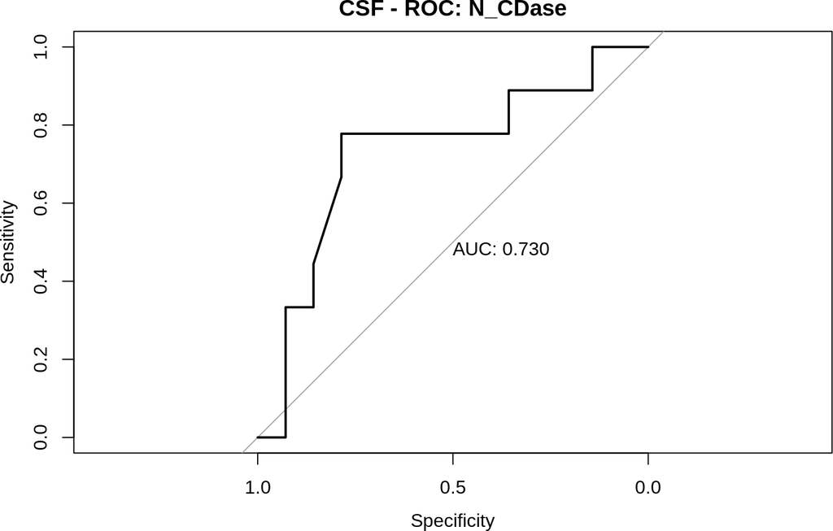

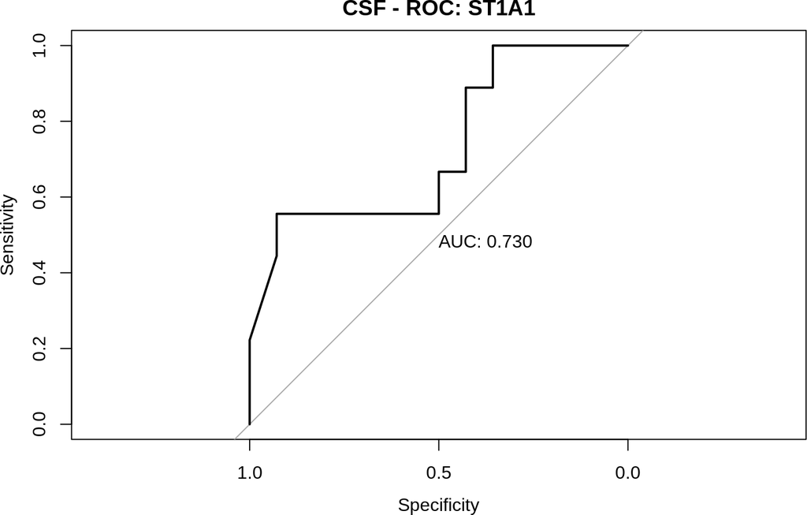

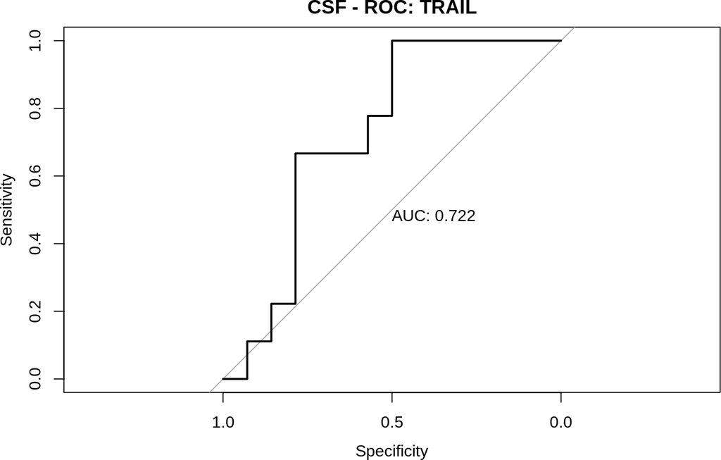

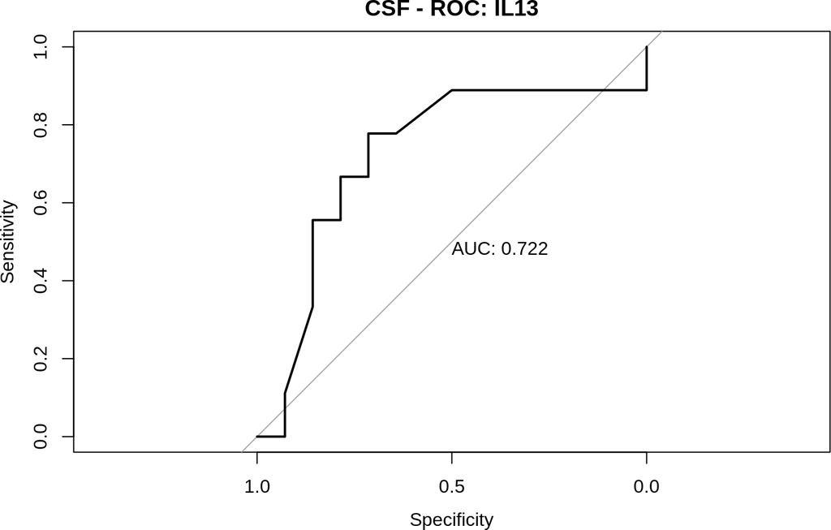

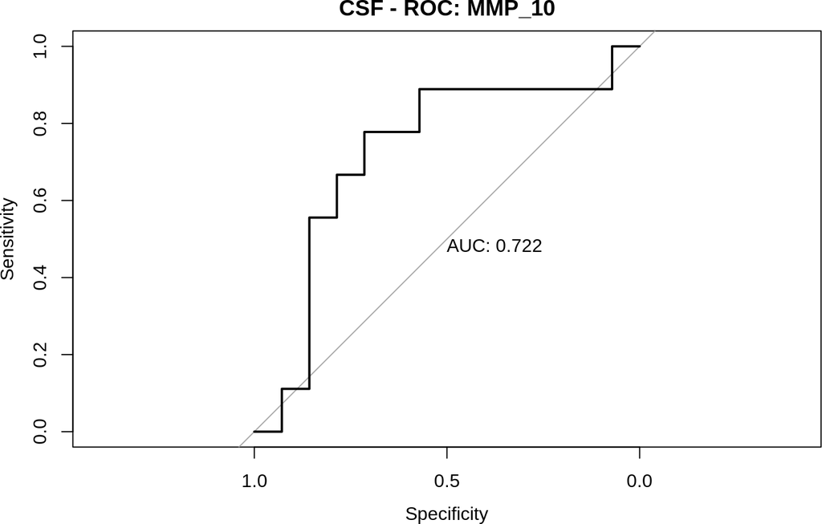

```r
best.csf <- dplyr::filter(as.data.frame(ROC_AUC_csf1), AUC>=0.7)


plot.csf <- lapply(arrange(best.csf, desc(AUC))$variables, function(x) {
  roc <- roc(LongCOVID ~ get(x), csf)
  plot(roc, print.auc=TRUE, main=paste0("CSF - ROC: ", x), xlim=c(1.2, -0.2))
  })
```

```r
pdf("plots/Revision_LongCovid_ROC_AUC_individual_prot_CSF.pdf")
lapply(arrange(best.csf, desc(AUC))$variables, function(x) {
  roc <- roc(LongCOVID ~ get(x), csf)
  plot(roc, print.auc=TRUE, main=paste0("CSF - ROC: ", x), xlim=c(1.2, -0.2))
  })
```

```
## [[1]]
##
## Call:
## roc.formula(formula = LongCOVID ~ get(x), data = csf)
##
## Data: get(x) in 14 controls (LongCOVID long_covid) > 9 cases (LongCOVID non_long_covid).
## Area under the curve: 0.7857
##
## [[2]]
##
## Call:
## roc.formula(formula = LongCOVID ~ get(x), data = csf)
##
## Data: get(x) in 14 controls (LongCOVID long_covid) > 9 cases (LongCOVID non_long_covid).
## Area under the curve: 0.7817
##
## [[3]]
##
## Call:
## roc.formula(formula = LongCOVID ~ get(x), data = csf)
##
## Data: get(x) in 14 controls (LongCOVID long_covid) < 9 cases (LongCOVID non_long_covid).
## Area under the curve: 0.7619
##
## [[4]]
##
## Call:
## roc.formula(formula = LongCOVID ~ get(x), data = csf)
##
## Data: get(x) in 14 controls (LongCOVID long_covid) > 9 cases (LongCOVID non_long_covid).
## Area under the curve: 0.746
##
## [[5]]
##
## Call:
## roc.formula(formula = LongCOVID ~ get(x), data = csf)
##
## Data: get(x) in 14 controls (LongCOVID long_covid) > 9 cases (LongCOVID non_long_covid).
## Area under the curve: 0.746
##
```

[output cut: 32 more lines]

```
## [[10]]
##
## Call:
## roc.formula(formula = LongCOVID ~ get(x), data = csf)
##
## Data: get(x) in 14 controls (LongCOVID long_covid) < 9 cases (LongCOVID non_long_covid).
## Area under the curve: 0.7222
##
## [[11]]
##
## Call:
## roc.formula(formula = LongCOVID ~ get(x), data = csf)
##
## Data: get(x) in 14 controls (LongCOVID long_covid) > 9 cases (LongCOVID non_long_covid).
## Area under the curve: 0.7222
```

```r
dev.off()
```

## 3.2 Boxplots

for visualisation purposes only

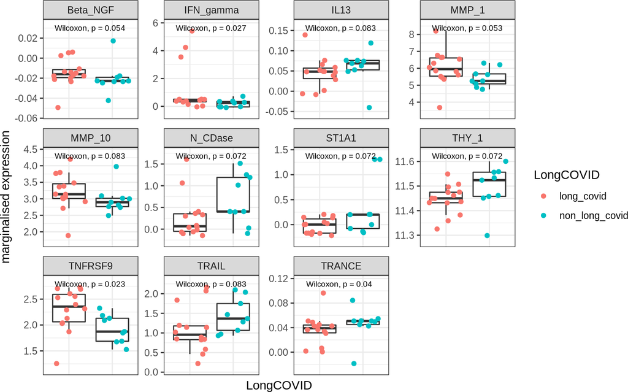

```r
boxplots.data.csf <- csf%>%
  dplyr::select(1:3, best.csf$variables)%>%
  pivot_longer(names_to = "protein", values_to = "marginalised expression", !c(StudyID, LongCOVID, COVID_class))

ggplot(boxplots.data.csf, aes(x=LongCOVID, y=`marginalised expression`))+
  theme_bw()+
  geom_boxplot(outlier.shape = NA)+
  geom_jitter(aes(color=LongCOVID))+
  theme(axis.text.x = element_blank(),
        axis.ticks.x = element_blank())+
  stat_compare_means(label.y.npc="top", label.x.npc = "left", size=2.5, position=position_nudge(y = 0.01))+
  scale_y_continuous(expand = expansion(mult = .15))+
  facet_wrap(~protein, scales= "free")
```

## 3.3 Logistic regression

### 3.3.1 full model

Full model including molecules with AUC>=0.7

```r
logit.csf <- glm(LongCOVID_01 ~ THY_1 + Beta_NGF + N_CDase + TRAIL + MMP_1 +
                   TRANCE + IL13 + MMP_10 + IFN_gamma + TNFRSF9 + ST1A1, data = csf,
                 family = "binomial")

summary(logit.csf)
```

```
##
## Call:
## glm(formula = LongCOVID_01 ~ THY_1 + Beta_NGF + N_CDase + TRAIL +
##     MMP_1 + TRANCE + IL13 + MMP_10 + IFN_gamma + TNFRSF9 + ST1A1,
##     family = "binomial", data = csf)
##
## Deviance Residuals:
##        Min          1Q      Median          3Q         Max
## -7.994e-06  -2.110e-08   2.110e-08   2.708e-06   6.446e-06
##
## Coefficients:
##               Estimate Std. Error z value Pr(>|z|)
## (Intercept) -1.259e+08  5.404e+12       0        1
## THY_1       -2.849e+01  2.485e+06       0        1
## Beta_NGF     2.209e+10  9.482e+14       0        1
## N_CDase     -1.698e+01  3.584e+05       0        1
## TRAIL       -6.671e+01  2.430e+05       0        1
## MMP_1        3.385e+00  2.202e+05       0        1
## TRANCE       1.042e+10  4.473e+14       0        1
## IL13         1.517e+09  6.509e+13       0        1
## MMP_10       1.742e+01  4.163e+05       0        1
## IFN_gamma    1.970e+01  2.154e+05       0        1
## TNFRSF9      2.998e+01  2.538e+05       0        1
## ST1A1       -1.389e+01  2.320e+05       0        1
##
## (Dispersion parameter for binomial family taken to be 1)
##
##     Null deviance: 3.0789e+01  on 22  degrees of freedom
## Residual deviance: 2.9807e-10  on 11  degrees of freedom
## AIC: 24
##
## Number of Fisher Scoring iterations: 25
```

#### 3.3.1.1 confusion matrix full model

```r
#use model to predict probability of default
predicted <- predict(logit.csf, csf, type="response")

#find optimal cutoff probability to use to maximize accuracy
optimal <- optimalCutoff(csf$LongCOVID_01, predicted)[1]

#create confusion matrix
conf.mat <- confusionMatrix(csf$LongCOVID_01, predicted)
conf.mat
```

```
##   0  1
## 0 9  0
## 1 0 14
```

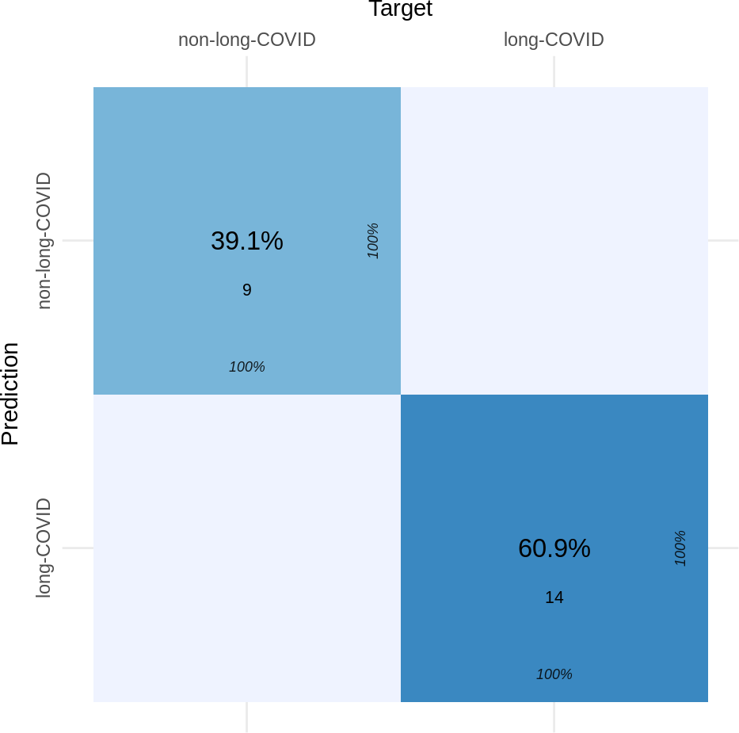

```r
Target <- factor(c("non-long-COVID", "non-long-COVID", "long-COVID", "long-COVID"))
Prediction <- factor(c("non-long-COVID", "long-COVID", "non-long-COVID", "long-COVID"))
N      <- c(conf.mat[1,1], conf.mat[2,1], conf.mat[1,2], conf.mat[2,2])
conf.mat2 <- data.frame(Target, Prediction, N)

plot_confusion_matrix(conf.mat2)
```

```r
pdf("plots/LongCOVID_prediction_CSF_confusion_matrix_full_model.pdf", width = 4, height=4)
plot_confusion_matrix(conf.mat2)
dev.off()
```

```r
#calculate sensitivity
sensitivity(csf$LongCOVID_01, predicted)
```

```
## [1] 1
```

```r
#calculate specificity
specificity(csf$LongCOVID_01, predicted)
```

```
## [1] 1
```

```r
#calculate total misclassification error rate
misClassError(csf$LongCOVID_01, predicted, threshold=optimal)
```

```
## [1] 0
```

As it stand this model shows an ability to perfectly predict it’s own training data.

#### 3.3.1.2 confusion matrix cross-validated full model

```r
train_and_evaluate = function( train , valid , target , params ){
  formula = paste( target , '~' , paste(params , collapse=' + '  )  )
  logit.csf <- glm(formula, data = train,
                 family = "binomial")

  predictedTrain <- predict(logit.csf, train, type="response")
  optimal <- optimalCutoff( train[ ,target] , predictedTrain)[1]

  predictedValid <- predict(logit.csf, valid, type="response")

  return( list( 'misClassError' = misClassError(valid[, target], predictedValid, threshold=optimal),
        'target'=valid[, target],
        'predicted' =predictedValid) )
}

CV_evaluate = function( data , target , params , k ){
  l = nrow(data)
  N = as.integer( l/k )
  fold = rep(1:k , N+1)[1:l]
  fold = sample(fold , l , replace = FALSE)

  CVR = list( 'misClassError' = c(),
        'target'=c(),
        'predicted' =c()  )

  for( i in 1:k ){
    valid = fold==i
    train = fold!=i

    foldR = train_and_evaluate( data[train , ] , data[valid,] , target , params )
    CVR[['misClassError']] = c(CVR[['misClassError']] , foldR[['misClassError']])
    CVR[['target']] = c(CVR[['target']] , foldR[['target']])
    CVR[['predicted']] = c(CVR[['predicted']] , foldR[['predicted']])
  }
  return( CVR )
}
```

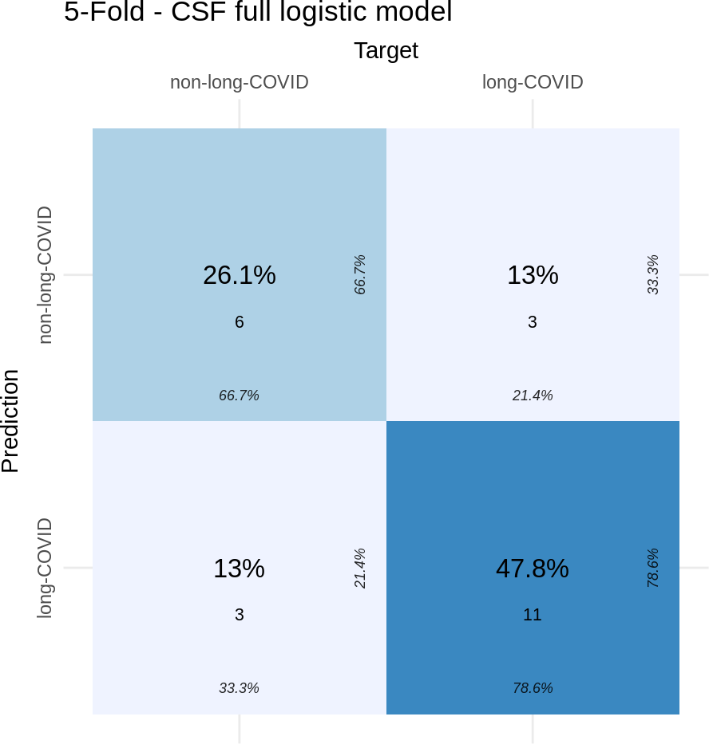

```r
set.seed(549267)


CVR = CV_evaluate( csf , "LongCOVID_01" ,
             c( "THY_1","Beta_NGF","N_CDase","TRAIL","MMP_1","TRANCE","IL13","MMP_10","IFN_gamma","TNFRSF9","ST1A1") ,
             k = 5 )


#create confusion matrix
conf.mat <- confusionMatrix( CVR$target, CVR$predicted)

Target <- factor(c("non-long-COVID", "non-long-COVID", "long-COVID", "long-COVID"))
Prediction <- factor(c("non-long-COVID", "long-COVID", "non-long-COVID", "long-COVID"))
N      <- c(conf.mat[1,1], conf.mat[2,1], conf.mat[1,2], conf.mat[2,2])
conf.mat2 <- data.frame(Target, Prediction, N)

plot_confusion_matrix(conf.mat2) + ggtitle('5-Fold - CSF full logistic model')
```

```r
print(summary( CVR$misClassError  ))
```

```
##    Min. 1st Qu.  Median    Mean 3rd Qu.    Max.
##    0.00    0.20    0.20    0.23    0.25    0.50
```

```r
pdf("plots/LongCOVID_prediction_CSF_confusion_matrix_CrossValidated_full_model.pdf", width = 4, height=4)
plot_confusion_matrix(conf.mat2) + ggtitle('5-Fold - CSF full logistic model')
dev.off()
```

Trying to split the data clearly shows degraded performances. The cross-validated missclassification error is 0.23.

So we strongly expect that we are overfitting but we also know we do not have enough data to regularize our model using train/validation split.

### 3.3.2 reduced model

backward selection can help us build a smaller model

```r
backward.select.csf <- step(logit.csf)
```

```
## Start:  AIC=24
## LongCOVID_01 ~ THY_1 + Beta_NGF + N_CDase + TRAIL + MMP_1 + TRANCE +
##     IL13 + MMP_10 + IFN_gamma + TNFRSF9 + ST1A1
##
##             Df   Deviance AIC
## - THY_1      1 3.0326e-10  22
## - MMP_1      1 3.1088e-10  22
## - Beta_NGF   1 3.1668e-10  22
## - TRANCE     1 3.1668e-10  22
## - IL13       1 3.1668e-10  22
## - ST1A1      1 3.4092e-10  22
## - MMP_10     1 3.4414e-10  22
## - N_CDase    1 3.6468e-10  22
## - TNFRSF9    1 4.1660e-10  22
## - IFN_gamma  1 1.2504e-09  22
## - TRAIL      1 1.4563e-09  22
## <none>         2.9807e-10  24
##
## Step:  AIC=22
## LongCOVID_01 ~ Beta_NGF + N_CDase + TRAIL + MMP_1 + TRANCE +
##     IL13 + MMP_10 + IFN_gamma + TNFRSF9 + ST1A1
##
##             Df   Deviance AIC
## - MMP_1      1 3.1663e-10  20
## - Beta_NGF   1 3.1765e-10  20
## - TRANCE     1 3.1765e-10  20
## - IL13       1 3.1765e-10  20
## - MMP_10     1 3.6814e-10  20
## - ST1A1      1 3.9322e-10  20
## - N_CDase    1 4.0211e-10  20
## - TNFRSF9    1 4.2807e-10  20
## - IFN_gamma  1 1.4083e-09  20
## - TRAIL      1 1.4842e-09  20
## <none>         3.0326e-10  22
##
## Step:  AIC=20
## LongCOVID_01 ~ Beta_NGF + N_CDase + TRAIL + TRANCE + IL13 + MMP_10 +
##     IFN_gamma + TNFRSF9 + ST1A1
##
##             Df   Deviance AIC
```

[output cut: 67 more lines]

```
##             Df Deviance    AIC
## - ST1A1      1   0.0000  8.000
## <none>           0.0000 10.000
## - TNFRSF9    1   5.7927 13.793
## - IFN_gamma  1  18.6724 26.672
## - TRAIL      1  18.9168 26.917
##
## Step:  AIC=8
## LongCOVID_01 ~ TRAIL + IFN_gamma + TNFRSF9
##
##             Df Deviance    AIC
## <none>            0.000  8.000
## - TNFRSF9    1   15.091 21.091
## - TRAIL      1   20.412 26.412
## - IFN_gamma  1   21.933 27.933
```

```r
summary(backward.select.csf)
```

```
##
## Call:
## glm(formula = LongCOVID_01 ~ TRAIL + IFN_gamma + TNFRSF9, family = "binomial",
##     data = csf)
##
## Deviance Residuals:
##        Min          1Q      Median          3Q         Max
## -2.589e-05  -2.110e-08   2.110e-08   2.110e-08   2.148e-05
##
## Coefficients:
##              Estimate Std. Error z value Pr(>|z|)
## (Intercept)     -3.30   96004.10   0.000    1.000
## TRAIL         -200.82  214915.98  -0.001    0.999
## IFN_gamma       64.01   73226.17   0.001    0.999
## TNFRSF9         94.61  116292.25   0.001    0.999
##
## (Dispersion parameter for binomial family taken to be 1)
##
##     Null deviance: 3.0789e+01  on 22  degrees of freedom
## Residual deviance: 1.3599e-09  on 19  degrees of freedom
## AIC: 8
##
## Number of Fisher Scoring iterations: 25
```

#### 3.3.2.1 confusion matrix best model

```r
best.model.csf <- glm(formula = LongCOVID_01 ~ TRAIL + IFN_gamma + TNFRSF9, family = "binomial",
    data = csf)

#use model to predict probability of default
predicted <- predict(best.model.csf, csf, type="response")

#find optimal cutoff probability to use to maximize accuracy
optimal <- optimalCutoff(csf$LongCOVID_01, predicted)[1]

#create confusion matrix
conf.mat <- confusionMatrix(csf$LongCOVID_01, predicted)
conf.mat
```

```
##   0  1
## 0 9  0
## 1 0 14
```

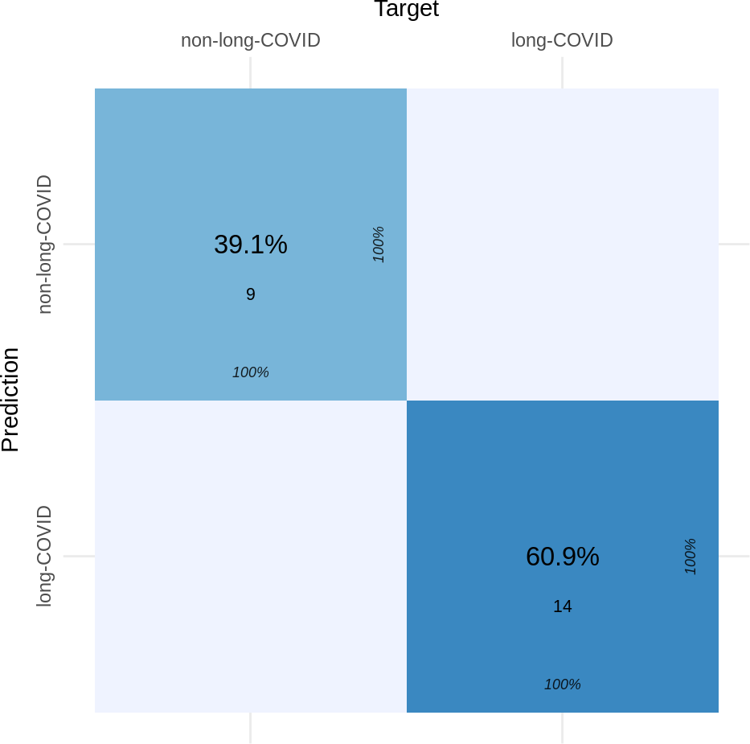

```r
Target <- factor(c("non-long-COVID", "non-long-COVID", "long-COVID", "long-COVID"))
Prediction <- factor(c("non-long-COVID", "long-COVID", "non-long-COVID", "long-COVID"))
N      <- c(conf.mat[1,1], conf.mat[2,1], conf.mat[1,2], conf.mat[2,2])
conf.mat2 <- data.frame(Target, Prediction, N)

plot_confusion_matrix(conf.mat2)
```

```r
pdf("plots/LongCOVID_prediction_CSF_confusion_matrix_best_model.pdf", width = 4, height=4)
plot_confusion_matrix(conf.mat2)
dev.off()
```

```r
#calculate sensitivity
sensitivity(csf$LongCOVID_01, predicted)
```

```
## [1] 1
```

```r
#calculate specificity
specificity(csf$LongCOVID_01, predicted)
```

```
## [1] 1
```

```r
#calculate total misclassification error rate
misClassError(csf$LongCOVID_01, predicted, threshold=optimal)
```

```
## [1] 0
```

Ok, so we are now down to only 3 molecules and still have very good performance !

- TRAIL
- IFN_gamma
- TNFRSF9

#### 3.3.2.2 confusion matrix cross-validated best model

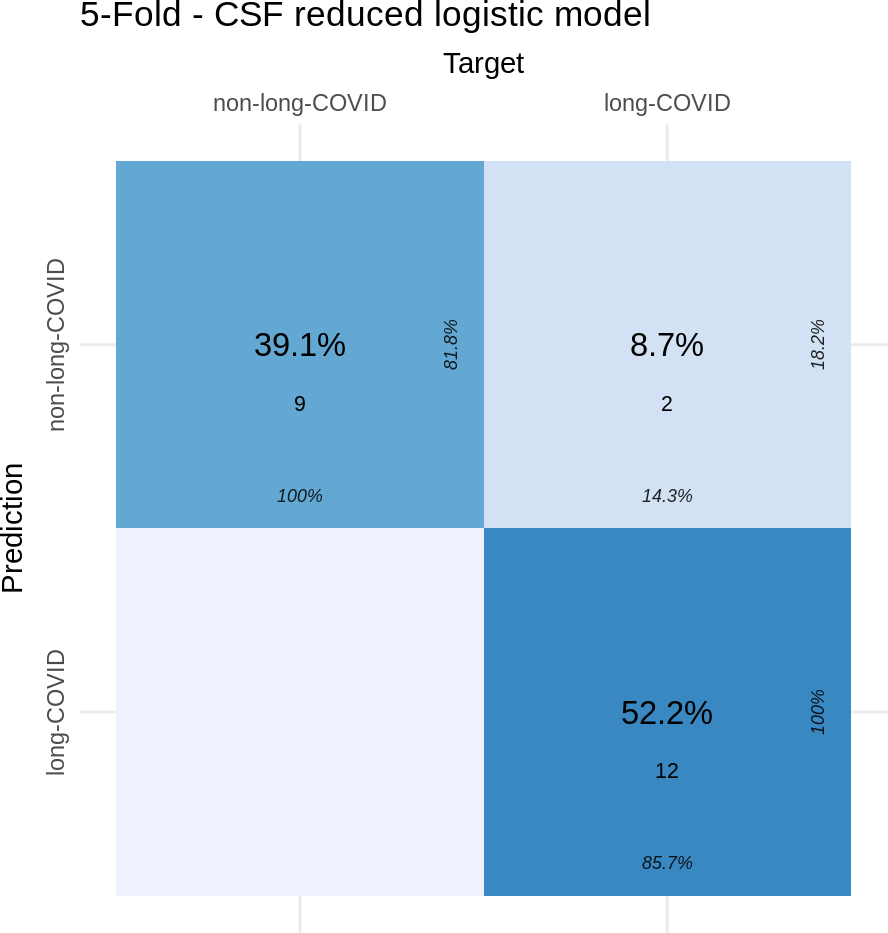

```r
set.seed(549267)

CVR = CV_evaluate( csf , "LongCOVID_01" ,
             c( "TRAIL","IFN_gamma","TNFRSF9") ,
             k = 5 )


#create confusion matrix
conf.mat <- confusionMatrix( CVR$target, CVR$predicted)

Target <- factor(c("non-long-COVID", "non-long-COVID", "long-COVID", "long-COVID"))
Prediction <- factor(c("non-long-COVID", "long-COVID", "non-long-COVID", "long-COVID"))
N      <- c(conf.mat[1,1], conf.mat[2,1], conf.mat[1,2], conf.mat[2,2])
conf.mat2 <- data.frame(Target, Prediction, N)

plot_confusion_matrix(conf.mat2) + ggtitle('5-Fold - CSF reduced logistic model')
```

```r
pdf("plots/LongCOVID_prediction_CSF_confusion_matrix_CrossValidated_best_model.pdf", width = 4, height=4)
plot_confusion_matrix(conf.mat2) + ggtitle('5-Fold - CSF reduced logistic model')
dev.off()
```

```r
print(summary( CVR$misClassError  ))
```

```
##    Min. 1st Qu.  Median    Mean 3rd Qu.    Max.
##    0.00    0.00    0.00    0.05    0.00    0.25
```

The cross-validated miss-classification error is 0.05, which is less than on the full model.

So it would appear we successfully reduced the model to something simpler and more general.

# 4 Prediction long COVID - **Plasma**

## 4.1 ROC-AUC Anaylsis long-COVID vs non-long COVID

```r
list.plasma <- colnames(plasma[,6:ncol(plasma)])

ROC_AUC_plasma <- lapply(list.plasma, function(x) {
  roc <- roc(LongCOVID ~ get(x), plasma)
  auc <- auc(roc)
  cbind(AUC = auc,
        gene = roc$call$predictor[3],
        variables = eval(x))
})

ROC_AUC_plasma1 <- do.call(rbind, ROC_AUC_plasma)

kable(ROC_AUC_plasma1[order(ROC_AUC_plasma1[,"AUC"],decreasing=TRUE),]) %>%
  kable_styling(position = "center", bootstrap_options = c("striped", "hover")) %>%
  scroll_box(width = "800px", height = "400px")
```

| AUC | variables |
| --- | --- |
| 0.883333333333333 | RGMA |
| 0.816666666666667 | CLM_6 |
| 0.75 | MCP_3 |
| 0.744444444444444 | GM_CSF_R_alpha |
| 0.744444444444444 | FcRL2 |
| 0.716666666666667 | GFR_alpha_1 |
| 0.716666666666667 | IL_1_alpha |
| 0.716666666666667 | DNER |
| 0.713888888888889 | IL_10RA |
| 0.711111111111111 | EZR |
| 0.705555555555556 | CD8A |
| 0.705555555555556 | TSLP |
| 0.702777777777778 | ST1A1 |
| 0.694444444444444 | EFNA4 |
| 0.688888888888889 | NMNAT1 |
| 0.683333333333333 | CNTN5 |
| 0.683333333333333 | G_CSF |
| 0.683333333333333 | FGF_23 |
| 0.683333333333333 | IL4 |
| 0.677777777777778 | Siglec_9 |
| 0.677777777777778 | VEGFA |
| 0.677777777777778 | HGF |
| 0.677777777777778 | CCL25 |
| 0.672222222222222 | MDGA1 |
| 0.672222222222222 | FGF_5 |
| 0.672222222222222 | IL13 |
| 0.666666666666667 | GDF_8 |
| 0.655555555555556 | BCAN |
| 0.65 | NTRK3 |
| 0.65 | CD6 |

[output cut: 152 more lines]

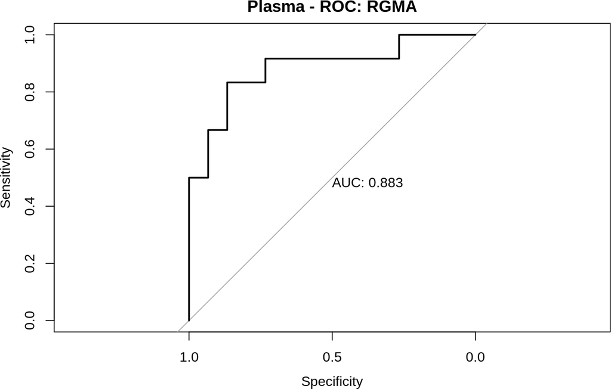

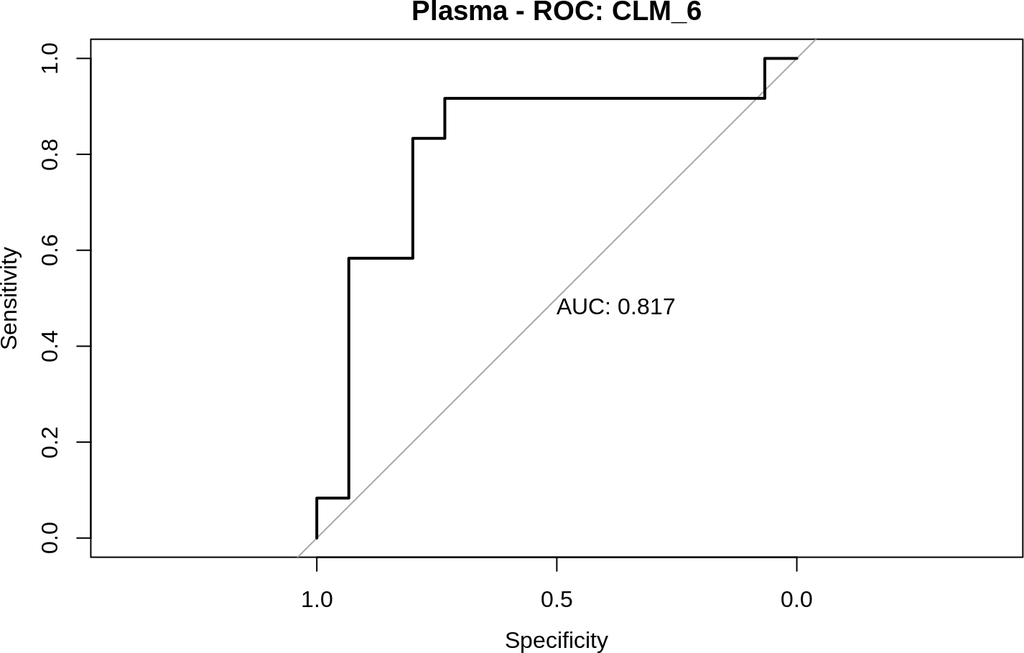

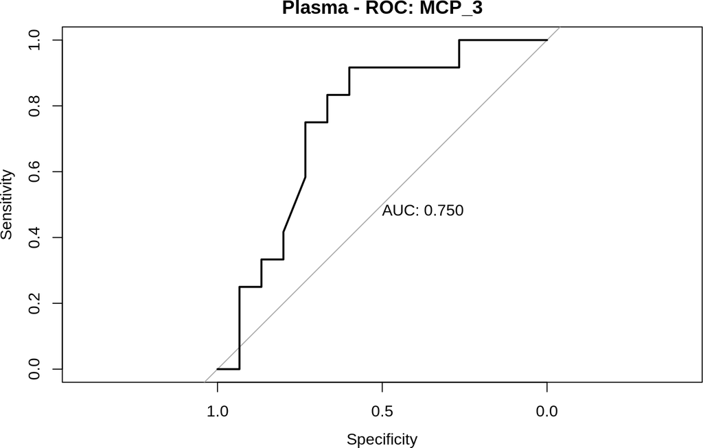

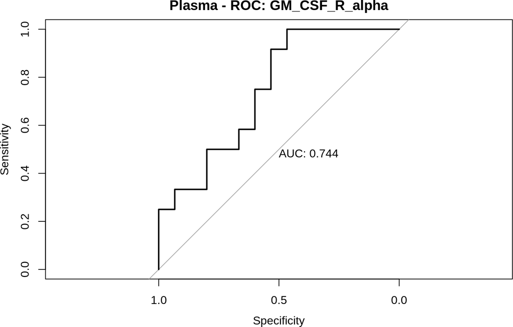

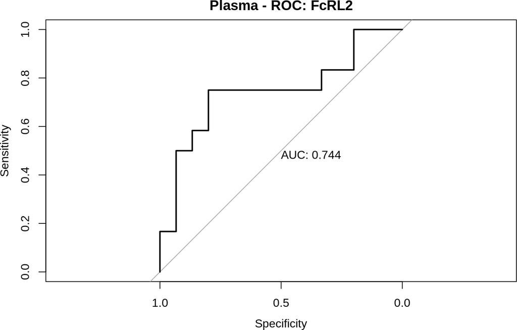

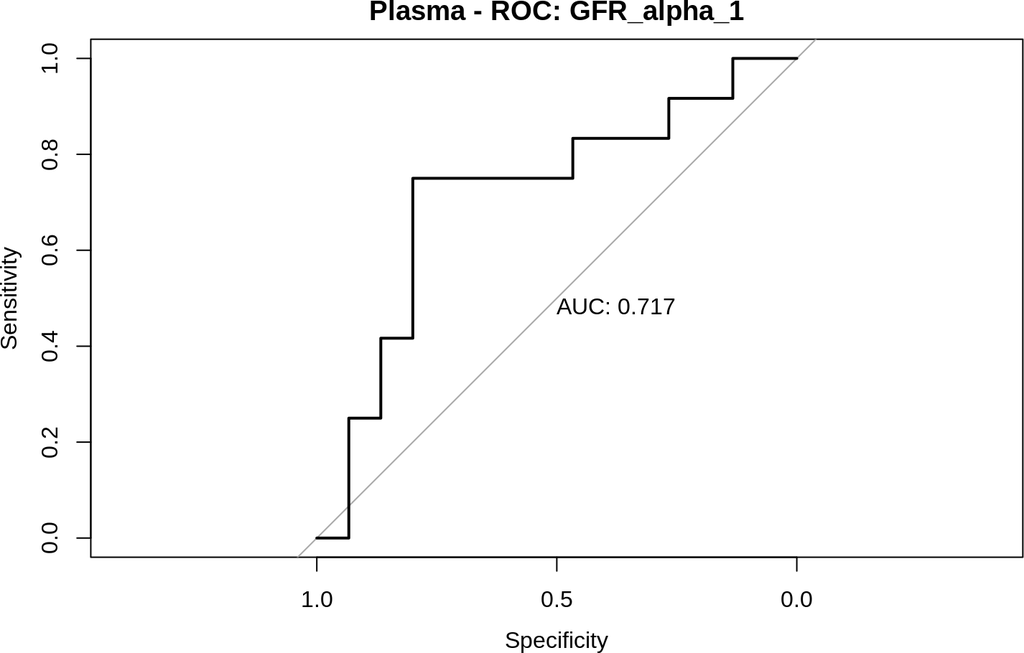

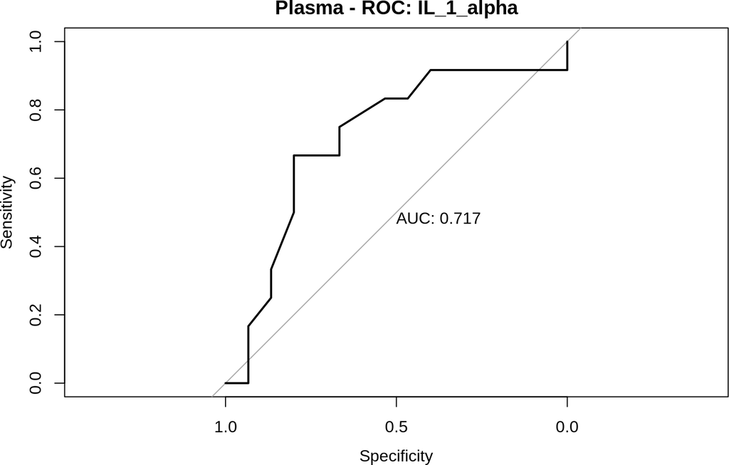

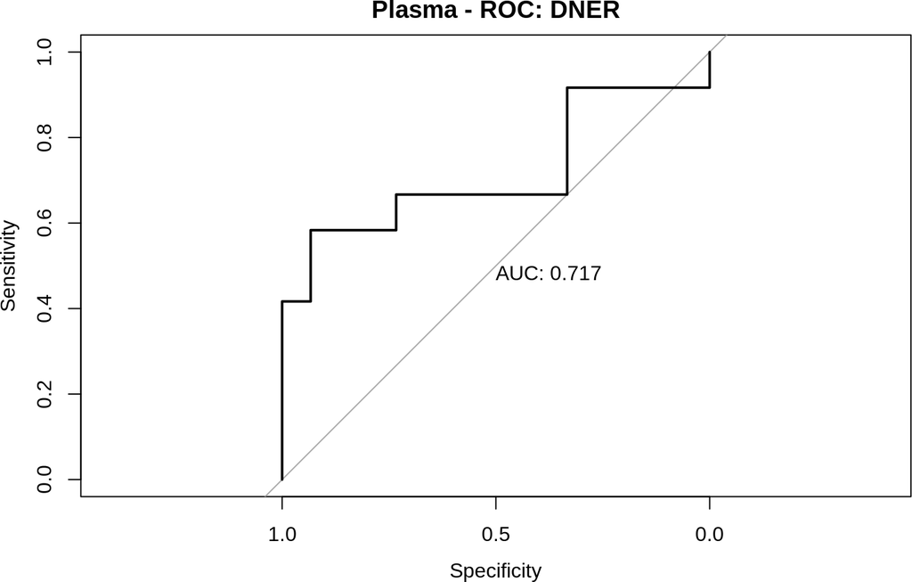

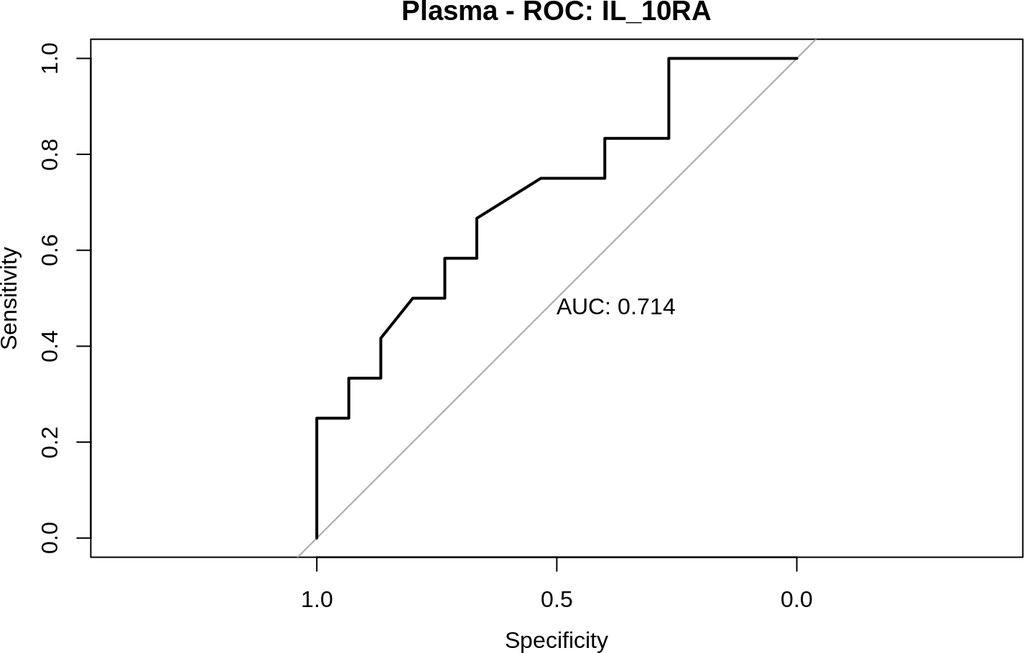

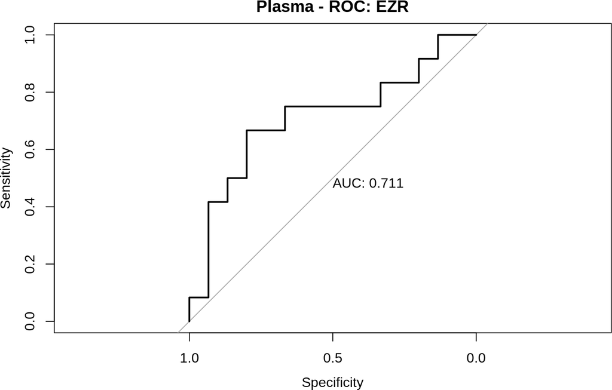

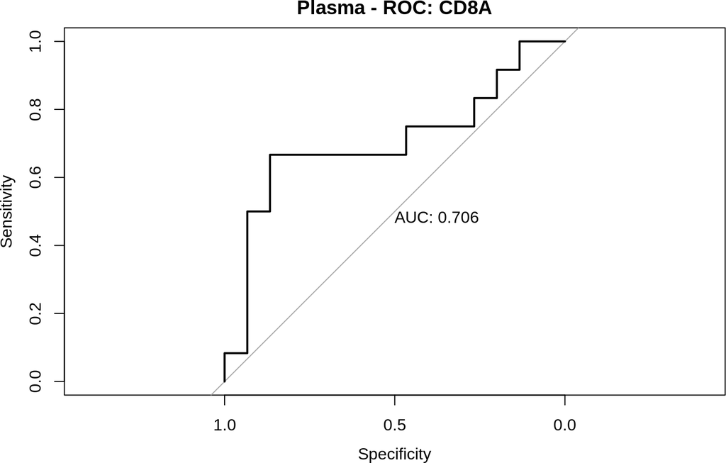

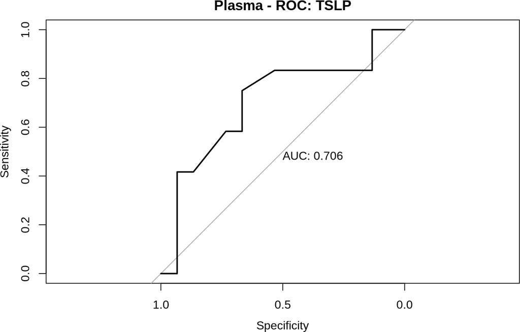

[1 more figures not shown]

```r
best.plasma <- dplyr::filter(as.data.frame(ROC_AUC_plasma1), AUC>=0.7)

# ggplot(dplyr::filter(plasma.lf, molec %in% best.plasma$variables), aes(d = labels, m = exp)) +
#   geom_roc()+
#   facet_wrap(~molec)

plot.plasma <- lapply(arrange(best.plasma, desc(AUC))$variables, function(x) {
  roc <- roc(LongCOVID ~ get(x), plasma)
  plot(roc, print.auc=TRUE, main=paste0("Plasma - ROC: ", x), xlim=c(1.2, -0.2))
  })
```

```r
pdf("plots/Revision_LongCovid_ROC_AUC_individual_prot_Plasma.pdf")
lapply(arrange(best.plasma, desc(AUC))$variables, function(x) {
  roc <- roc(LongCOVID ~ get(x), plasma)
  plot(roc, print.auc=TRUE, main=paste0("Plasma - ROC: ", x), xlim=c(1.2, -0.2))
  })
```

```
## [[1]]
##
## Call:
## roc.formula(formula = LongCOVID ~ get(x), data = plasma)
##
## Data: get(x) in 15 controls (LongCOVID long_covid) < 12 cases (LongCOVID non_long_covid).
## Area under the curve: 0.8833
##
## [[2]]
##
## Call:
## roc.formula(formula = LongCOVID ~ get(x), data = plasma)
##
## Data: get(x) in 15 controls (LongCOVID long_covid) > 12 cases (LongCOVID non_long_covid).
## Area under the curve: 0.8167
##
## [[3]]
##
## Call:
## roc.formula(formula = LongCOVID ~ get(x), data = plasma)
##
## Data: get(x) in 15 controls (LongCOVID long_covid) > 12 cases (LongCOVID non_long_covid).
## Area under the curve: 0.75
##
## [[4]]
##
## Call:
## roc.formula(formula = LongCOVID ~ get(x), data = plasma)
##
## Data: get(x) in 15 controls (LongCOVID long_covid) > 12 cases (LongCOVID non_long_covid).
## Area under the curve: 0.7444
##
## [[5]]
##
## Call:
## roc.formula(formula = LongCOVID ~ get(x), data = plasma)
##
## Data: get(x) in 15 controls (LongCOVID long_covid) > 12 cases (LongCOVID non_long_covid).
## Area under the curve: 0.7444
##
```

[output cut: 48 more lines]

```
## [[12]]
##
## Call:
## roc.formula(formula = LongCOVID ~ get(x), data = plasma)
##
## Data: get(x) in 15 controls (LongCOVID long_covid) > 12 cases (LongCOVID non_long_covid).
## Area under the curve: 0.7056
##
## [[13]]
##
## Call:
## roc.formula(formula = LongCOVID ~ get(x), data = plasma)
##
## Data: get(x) in 15 controls (LongCOVID long_covid) < 12 cases (LongCOVID non_long_covid).
## Area under the curve: 0.7028
```

```r
dev.off()
```

## 4.2 Boxplots

for visualisation purposes only

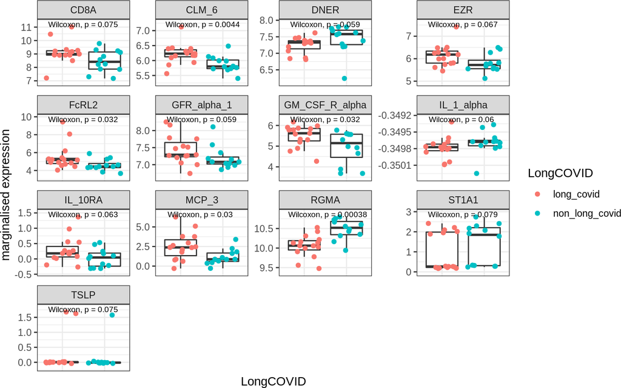

```r
boxplots.data.plasma <- plasma%>%
  dplyr::select(1:3, best.plasma$variables)%>%
  pivot_longer(names_to = "protein", values_to = "marginalised expression", !c(StudyID, LongCOVID, COVID_class))


ggplot(boxplots.data.plasma, aes(x=LongCOVID, y=`marginalised expression`))+
  theme_bw()+
  geom_boxplot(outlier.shape = NA)+
  geom_jitter(aes(color=LongCOVID))+
  theme(axis.text.x = element_blank(),
        axis.ticks.x = element_blank())+
  stat_compare_means(label.y.npc="top", label.x.npc = "left", size=2.5)+
  scale_y_continuous(expand = expansion(mult = .15))+
  facet_wrap(~protein, scales= "free")
```

## 4.3 logistic regression

### 4.3.1 full model

full model including molecules with AUC>=0.7

```r
logit.plasma <- glm(LongCOVID_01 ~ CLM_6 + EZR + RGMA + GFR_alpha_1 + GM_CSF_R_alpha +
                   FcRL2 + CD8A + MCP_3 + IL_1_alpha + TSLP + IL_10RA + DNER + ST1A1,
                   data = plasma, family = "binomial")

summary(logit.plasma)
```

```
##
## Call:
## glm(formula = LongCOVID_01 ~ CLM_6 + EZR + RGMA + GFR_alpha_1 +
##     GM_CSF_R_alpha + FcRL2 + CD8A + MCP_3 + IL_1_alpha + TSLP +
##     IL_10RA + DNER + ST1A1, family = "binomial", data = plasma)
##
## Deviance Residuals:
##        Min          1Q      Median          3Q         Max
## -1.392e-05  -2.110e-08   2.110e-08   4.121e-06   1.240e-05
##
## Coefficients:
##                  Estimate Std. Error z value Pr(>|z|)
## (Intercept)    -2.608e+04  3.671e+08   0.000        1
## CLM_6           4.858e+01  5.717e+05   0.000        1
## EZR             1.107e+02  2.398e+05   0.000        1
## RGMA           -6.650e+01  5.679e+05   0.000        1
## GFR_alpha_1    -4.950e+01  3.760e+05   0.000        1
## GM_CSF_R_alpha -1.727e+01  9.571e+04   0.000        1
## FcRL2           3.018e+01  5.487e+04   0.001        1
## CD8A           -4.266e+00  2.658e+05   0.000        1
## MCP_3          -5.775e+00  4.737e+04   0.000        1
## IL_1_alpha     -7.520e+04  1.058e+09   0.000        1
## TSLP           -2.972e+01  1.337e+05   0.000        1
## IL_10RA         6.996e+01  3.938e+05   0.000        1
## DNER           -1.677e+01  2.968e+05   0.000        1
## ST1A1          -2.086e+01  8.318e+04   0.000        1
##
## (Dispersion parameter for binomial family taken to be 1)
##
##     Null deviance: 3.7096e+01  on 26  degrees of freedom
## Residual deviance: 9.4425e-10  on 13  degrees of freedom
## AIC: 28
##
## Number of Fisher Scoring iterations: 25
```

#### 4.3.1.1 confusion matrix full model

```r
#use model to predict probability of default
predicted <- predict(logit.plasma, plasma, type="response")

#find optimal cutoff probability to use to maximize accuracy
optimal <- optimalCutoff(plasma$LongCOVID_01, predicted)[1]

#create confusion matrix
conf.mat <- confusionMatrix(plasma$LongCOVID_01, predicted)
conf.mat
```

```
##    0  1
## 0 12  0
## 1  0 15
```

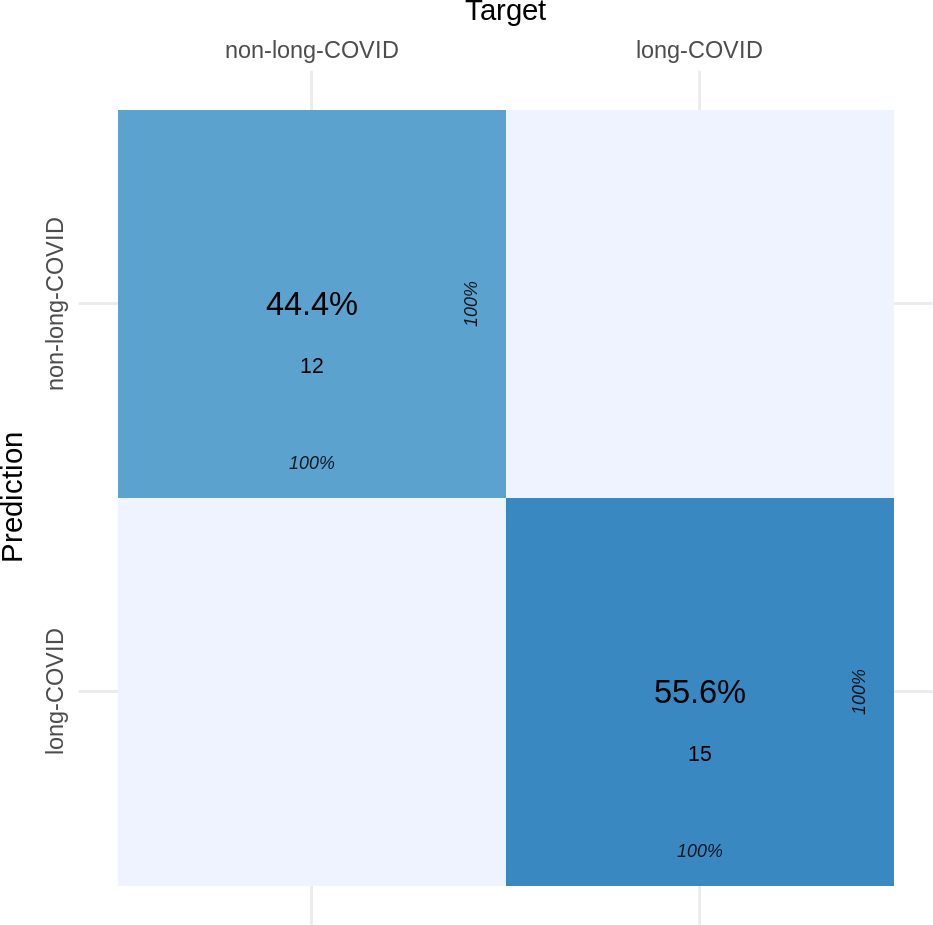

```r
Target <- factor(c("non-long-COVID", "non-long-COVID", "long-COVID", "long-COVID"))
Prediction <- factor(c("non-long-COVID", "long-COVID", "non-long-COVID", "long-COVID"))
N      <- c(conf.mat[1,1], conf.mat[2,1], conf.mat[1,2], conf.mat[2,2])
conf.mat2 <- data.frame(Target, Prediction, N)

plot_confusion_matrix(conf.mat2)
```

```r
pdf("plots/LongCOVID_prediction_PLASMA_confusion_matrix_full_model.pdf", width = 4, height=4)
plot_confusion_matrix(conf.mat2)
dev.off()
```

```r
#calculate sensitivity
sensitivity(plasma$LongCOVID_01, predicted)
```

```
## [1] 1
```

```r
#calculate specificity
specificity(plasma$LongCOVID_01, predicted)
```

```
## [1] 1
```

```r
#calculate total misclassification error rate
misClassError(plasma$LongCOVID_01, predicted, threshold=optimal)
```

```
## [1] 0
```

#### 4.3.1.2 confusion matrix cross-validated full model

Let’s see how a full model behaves when cross validated

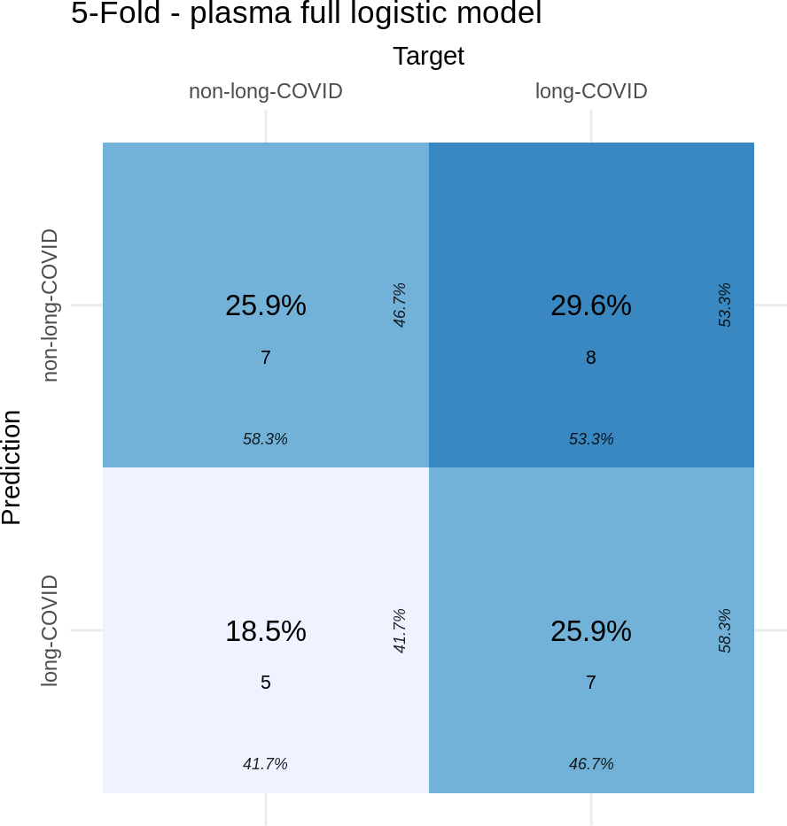

```r
set.seed(549267)

CVR = CV_evaluate( plasma , "LongCOVID_01" ,
             c("CLM_6","EZR","RGMA","GFR_alpha_1","GM_CSF_R_alpha","FcRL2","CD8A","MCP_3","IL_1_alpha","TSLP","IL_10RA","DNER","ST1A1"),
             k = 5 )


#create confusion matrix
conf.mat <- confusionMatrix( CVR$target, CVR$predicted)

Target <- factor(c("non-long-COVID", "non-long-COVID", "long-COVID", "long-COVID"))
Prediction <- factor(c("non-long-COVID", "long-COVID", "non-long-COVID", "long-COVID"))
N      <- c(conf.mat[1,1], conf.mat[2,1], conf.mat[1,2], conf.mat[2,2])
conf.mat2 <- data.frame(Target, Prediction, N)

plot_confusion_matrix(conf.mat2) + ggtitle('5-Fold - plasma full logistic model')
```

```r
pdf("plots/LongCOVID_prediction_PLASMA_confusion_matrix_CrossValidated_full_model.pdf", width = 4, height=4)
plot_confusion_matrix(conf.mat2) + ggtitle('5-Fold - plasma full logistic model')
dev.off()
```

```r
print(summary( CVR$misClassError  ))
```

```
##    Min. 1st Qu.  Median    Mean 3rd Qu.    Max.
##    0.00    0.50    0.50    0.48    0.60    0.80
```

It looks like the full model approach grossly overfit here, with a cross-validated average missclassification error of 0.48.

Again, let’s use backward selection to reduce the model

### 4.3.2 reduced model

```r
backward.select.plasma <- step(logit.plasma)
```

```
## Start:  AIC=28
## LongCOVID_01 ~ CLM_6 + EZR + RGMA + GFR_alpha_1 + GM_CSF_R_alpha +
##     FcRL2 + CD8A + MCP_3 + IL_1_alpha + TSLP + IL_10RA + DNER +
##     ST1A1
##
##                  Df   Deviance AIC
## - CD8A            1 9.6030e-10  26
## - CLM_6           1 9.8050e-10  26
## - DNER            1 1.0142e-09  26
## - MCP_3           1 1.0580e-09  26
## - GFR_alpha_1     1 1.0942e-09  26
## - IL_10RA         1 1.2241e-09  26
## - IL_1_alpha      1 1.3050e-09  26
## - GM_CSF_R_alpha  1 1.3668e-09  26
## - RGMA            1 1.3700e-09  26
## - TSLP            1 1.4598e-09  26
## - ST1A1           1 1.5078e-09  26
## - EZR             1 1.9593e-09  26
## - FcRL2           1 1.9914e-08  26
## <none>              9.4430e-10  28
##
## Step:  AIC=26
## LongCOVID_01 ~ CLM_6 + EZR + RGMA + GFR_alpha_1 + GM_CSF_R_alpha +
##     FcRL2 + MCP_3 + IL_1_alpha + TSLP + IL_10RA + DNER + ST1A1
##
##                  Df   Deviance AIC
## - DNER            1 1.0451e-09  24
## - MCP_3           1 1.0900e-09  24
## - CLM_6           1 1.0943e-09  24
## - GFR_alpha_1     1 1.1232e-09  24
## - GM_CSF_R_alpha  1 1.3790e-09  24
## - IL_10RA         1 1.4209e-09  24
## - IL_1_alpha      1 1.4298e-09  24
## - RGMA            1 1.7974e-09  24
## - TSLP            1 1.9335e-09  24
## - EZR             1 2.0001e-09  24
## - ST1A1           1 5.0687e-09  24
## - FcRL2           1 2.8155e-08  24
## <none>              9.6030e-10  26
##
```

[output cut: 97 more lines]

```
## <none>        0.000 12.000
## - ST1A1  1    6.419 16.419
## - EZR    1   14.747 24.747
## - FcRL2  1   15.493 25.494
## - RGMA   1   25.780 35.780
##
## Step:  AIC=10
## LongCOVID_01 ~ EZR + RGMA + FcRL2 + ST1A1
##
##         Df Deviance    AIC
## <none>       0.0000 10.000
## - ST1A1  1   6.5482 14.548
## - EZR    1  15.3795 23.380
## - FcRL2  1  15.5465 23.547
## - RGMA   1  26.0457 34.046
```

```r
summary(backward.select.plasma)
```

```
##
## Call:
## glm(formula = LongCOVID_01 ~ EZR + RGMA + FcRL2 + ST1A1, family = "binomial",
##     data = plasma)
##
## Deviance Residuals:
##        Min          1Q      Median          3Q         Max
## -1.377e-04  -2.100e-08   2.100e-08   2.100e-08   1.333e-04
##
## Coefficients:
##              Estimate Std. Error z value Pr(>|z|)
## (Intercept)    4590.8  1047285.1   0.004    0.997
## EZR             678.2   157373.0   0.004    0.997
## RGMA          -1041.5   236593.4  -0.004    0.996
## FcRL2           453.0   103007.5   0.004    0.996
## ST1A1          -180.9    71141.0  -0.003    0.998
##
## (Dispersion parameter for binomial family taken to be 1)
##
##     Null deviance: 3.7096e+01  on 26  degrees of freedom
## Residual deviance: 4.4662e-08  on 22  degrees of freedom
## AIC: 10
##
## Number of Fisher Scoring iterations: 25
```